# Untitled

## Library/Packages

```r
library("forecast")
```

```r
library("graphics")
library("TTR")
library("TSA")
```

## Impor Data

```r
library(rio)
data <- import("https://raw.githubusercontent.com/Feaann/mpdw/main/Pertemuan%201/Tugas/Data%20100%20Periode.xlsx")

# menampilkan 5 data pertama
head(data)
```

```
##      Tanggal Jumlah Penumpang Monorail
## 1 2024-02-13                     56343
## 2 2024-02-14                     56279
## 3 2024-02-15                     55506
## 4 2024-02-16                     55202
## 5 2024-02-17                     43440
## 6 2024-02-18                     40257
```

## Eksplorasi Data

`View()` : menampilkan data dalam bentuk tabel, `str()` : menampilkan struktur data, `dim()` : menampilkan dimensi data

```r
View(data)
str(data)
```

```
## 'data.frame':    100 obs. of  2 variables:
##  $ Tanggal                  : chr  "2024-02-13" "2024-02-14" "2024-02-15" "2024-02-16" ...
##  $ Jumlah Penumpang Monorail: num  56343 56279 55506 55202 43440 ...
```

```r
dim(data)
```

```
## [1] 100   2
```

Mengubah data agar terbaca sebagai data deret waktu dengan fungsi `ts()` .

```r
data.ts <- ts(data$'Jumlah Penumpang Monorail')
```

Menampilkan ringkasan data

```r
summary(data.ts)
```

```
##    Min. 1st Qu.  Median    Mean 3rd Qu.    Max.
##   28097   47883   53461   51772   56239   62956
```

Membuat plot data deret waktu

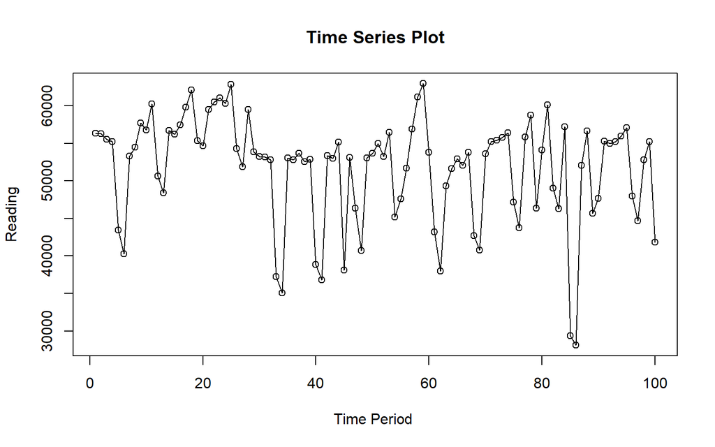

```r
ts.plot(data.ts, xlab="Time Period ", ylab="Reading",
        main = "Time Series Plot")
points(data.ts)
```

```r
#menyimpan plot
dev.copy(png, "plot_data1.png")
```

```r
dev.off()
```

## Single Moving Average & Double Moving Average

### Pembagian Data

Pembagian data latih dan data uji dilakukan dengan perbandingan 80% data latih dan 20% data uji.

```r
# hitung jumlah data
n <- nrow(data)

# tentukan batas 80%
n_train <- floor(0.8 * n)

# bagi data
training_ma <- data[1:n_train, ]
testing_ma  <- data[(n_train+1):n, ]

# ubah ke time series
train_ma.ts <- ts(training_ma$'Jumlah Penumpang Monorail')
test_ma.ts  <- ts(testing_ma$'Jumlah Penumpang Monorail')
```

Eksplorasi data dilakukan pada keseluruhan data, data latih serta data uji menggunakan plot data deret waktu.

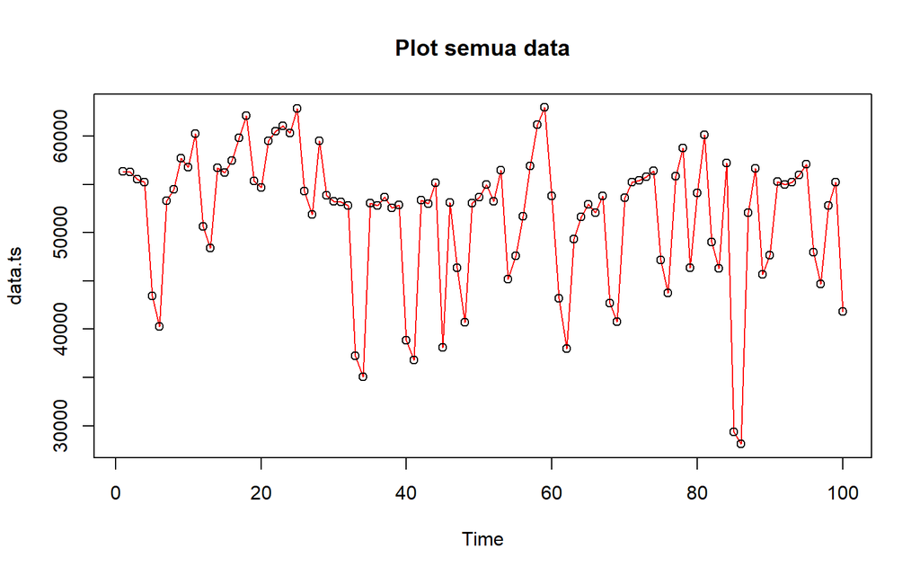

```r
#eksplorasi keseluruhan data
plot(data.ts, col="red",main="Plot semua data")
points(data.ts)
```

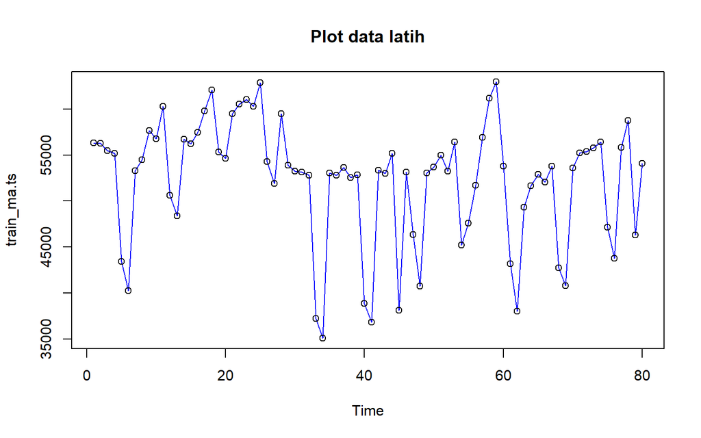

```r
#eksplorasi data latih
plot(train_ma.ts, col="blue",main="Plot data latih")
points(train_ma.ts)
```

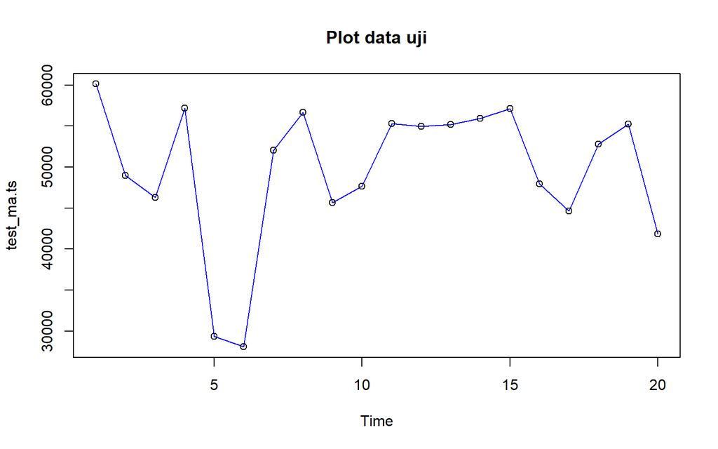

```r
#eksplorasi data uji
plot(test_ma.ts, col="blue",main="Plot data uji")
points(test_ma.ts)
```

Eksplorasi data juga dapat dilakukan menggunakan package `ggplot2` dengan terlebih dahulu memanggil library *package* `ggplot2`.

```r
training_ma$Tanggal <- as.Date(training_ma$Tanggal)
testing_ma$Tanggal <- as.Date(testing_ma$Tanggal)
```

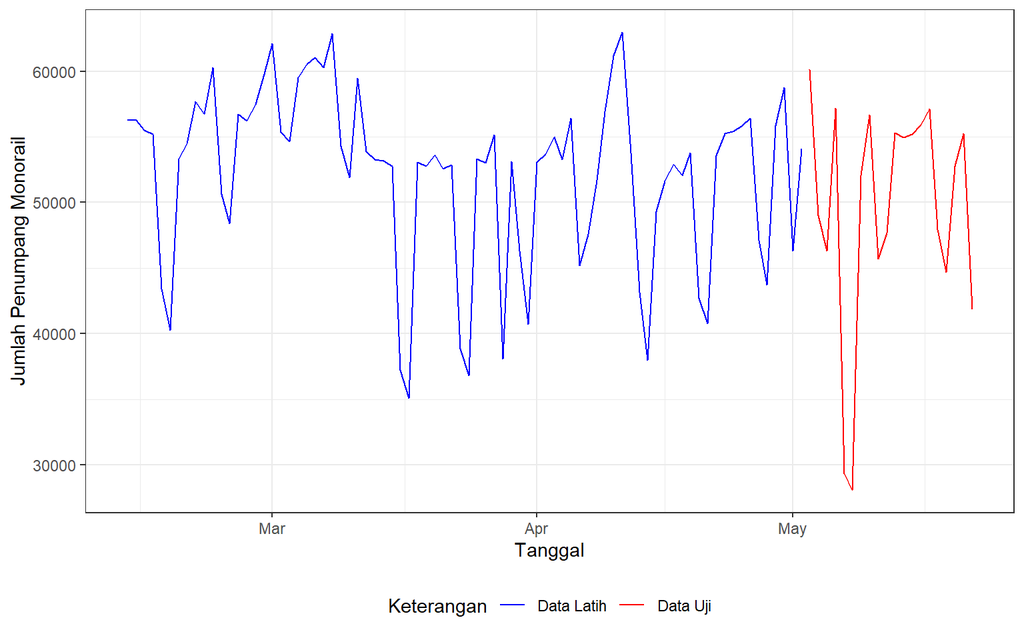

```r
library(ggplot2)
ggplot() +
  geom_line(
    data = training_ma,
    aes(
      x = Tanggal,
      y = `Jumlah Penumpang Monorail`,
      color = "Data Latih",
      group = 1
    )
  ) +
  geom_line(
    data = testing_ma,
    aes(
      x = Tanggal,
      y = `Jumlah Penumpang Monorail`,
      color = "Data Uji",
      group = 1
    )
  ) +
  labs(
    x = "Tanggal",
    y = "Jumlah Penumpang Monorail",
    color = "Keterangan"
  ) +
  scale_colour_manual(
    values = c(
      "Data Latih" = "blue",
      "Data Uji" = "red"
    )
  ) +
  theme_bw() +
  theme(
    legend.position = "bottom"
  )
```

### Single Moving Average (SMA)

Ide dasar dari Single Moving Average (SMA) adalah data suatu periode dipengaruhi oleh data periode sebelumnya. Metode pemulusan ini cocok digunakan untuk pola data stasioner atau konstan. Prinsip dasar metode pemulusan ini adalah data pemulusan pada periode ke-t merupakan rata rata dari m buah data pada periode ke-t hingga periode ke (t-m+1).

$$S_t = \frac{1}{m} \sum_{i=t-m+1}^{t} X_i$$

Data pemulusan pada periode ke-t selanjutnya digunakan sebagai nilai peramalan pada periode ke t+1.

$$F_t = S_{t-1}, F_{n,h} = S_n$$

Pemulusan menggunakan metode SMA dilakukan dengan fungsi `SMA()`. Dalam hal ini akan dilakukan pemulusan dengan parameter `m=4`.

```r
data.sma<-SMA(train_ma.ts, n=4)
data.sma
```

```
## Time Series:
## Start = 1
## End = 80
## Frequency = 1
##  [1]       NA       NA       NA 55832.50 52606.75 48601.25 48052.75 47876.50
##  [9] 51437.50 55561.50 57301.50 56337.00 54010.00 54004.00 52992.50 54699.25
## [17] 57554.00 58894.00 58672.00 57970.75 57902.75 57511.75 58937.50 60345.75
## [25] 61184.25 59628.75 57344.25 57140.25 54890.00 54628.25 54943.25 53271.25
## [33] 49104.25 44559.75 44531.00 44529.25 48640.50 53007.75 52959.50 49478.50
## [41] 45266.50 45464.00 45500.75 49579.75 49901.75 49850.00 48183.25 44572.25
## [49] 48312.00 48453.75 50615.75 53745.50 54593.75 52468.25 50616.00 50226.75
## [57] 50344.25 54344.75 58190.25 58711.00 55279.25 49479.50 46074.00 45539.75
## [65] 47973.75 51486.75 52600.25 50368.00 47334.25 47717.75 48082.75 51254.00
## [73] 55007.00 55712.00 53684.75 50773.00 50782.75 51375.25 51172.25 53755.50
```

Data pemulusan pada periode ke-t selanjutnya digunakan sebagai nilai peramalan pada periode ke t+1 sehingga hasil peramalan 1 periode kedepan adalah sebagai berikut.

```r
data.ramal<-c(NA,data.sma)
data.ramal #forecast 1 periode ke depan
```

```
##  [1]       NA       NA       NA       NA 55832.50 52606.75 48601.25 48052.75
##  [9] 47876.50 51437.50 55561.50 57301.50 56337.00 54010.00 54004.00 52992.50
## [17] 54699.25 57554.00 58894.00 58672.00 57970.75 57902.75 57511.75 58937.50
## [25] 60345.75 61184.25 59628.75 57344.25 57140.25 54890.00 54628.25 54943.25
## [33] 53271.25 49104.25 44559.75 44531.00 44529.25 48640.50 53007.75 52959.50
## [41] 49478.50 45266.50 45464.00 45500.75 49579.75 49901.75 49850.00 48183.25
## [49] 44572.25 48312.00 48453.75 50615.75 53745.50 54593.75 52468.25 50616.00
## [57] 50226.75 50344.25 54344.75 58190.25 58711.00 55279.25 49479.50 46074.00
## [65] 45539.75 47973.75 51486.75 52600.25 50368.00 47334.25 47717.75 48082.75
## [73] 51254.00 55007.00 55712.00 53684.75 50773.00 50782.75 51375.25 51172.25
## [81] 53755.50
```

Selanjutnya dilakukan peramalan sebanyak 20 periode sesuai dengan jumlah data uji. Pada metode SMA, seluruh hasil peramalan untuk 20 periode ke depan akan memiliki nilai yang sama dengan hasil ramalan satu periode ke depan.

```r
data.gab <- cbind(
  aktual = c(data.ts),
  pemulusan = c(data.sma, rep(NA, 20)),
  ramalan = c(data.ramal, rep(data.ramal[length(data.ramal)], 19))
)

data.gab #forecast 20 periode ke depan
```

```
##        aktual pemulusan  ramalan
##   [1,]  56343        NA       NA
##   [2,]  56279        NA       NA
##   [3,]  55506        NA       NA
##   [4,]  55202  55832.50       NA
##   [5,]  43440  52606.75 55832.50
##   [6,]  40257  48601.25 52606.75
##   [7,]  53312  48052.75 48601.25
##   [8,]  54497  47876.50 48052.75
##   [9,]  57684  51437.50 47876.50
##  [10,]  56753  55561.50 51437.50
##  [11,]  60272  57301.50 55561.50
##  [12,]  50639  56337.00 57301.50
##  [13,]  48376  54010.00 56337.00
##  [14,]  56729  54004.00 54010.00
```

[output cut: 86 more lines]

Adapun plot data deret waktu dari hasil peramalan yang dilakukan adalah sebagai berikut.

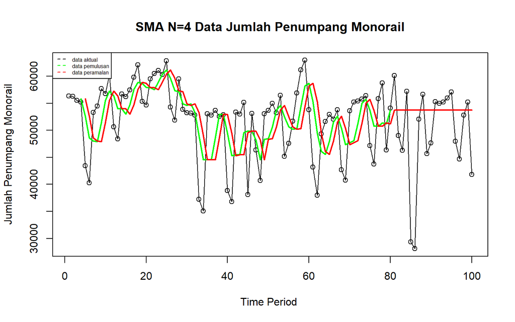

```r
ts.plot(data.ts, xlab="Time Period ", ylab="Jumlah Penumpang Monorail", main= "SMA N=4 Data Jumlah Penumpang Monorail")
points(data.ts)
lines(data.gab[,2],col="green",lwd=2)
lines(data.gab[,3],col="red",lwd=2)
legend("topleft",c("data aktual","data pemulusan","data peramalan"), lty=8, col=c("black","green","red"), cex=0.5)
```

Selanjutnya perhitungan akurasi dilakukan dengan ukuran akurasi *Sum Squares Error* (SSE), *Mean Square Error* (MSE) dan *Mean Absolute Percentage Error* (MAPE). Perhitungan akurasi dilakukan baik pada data latih maupun pada data uji.

$$SSE = \sum_{t=1}^{n} (y_t - \hat{y}_t)^2$$
$$MSE = \frac{1}{n} \sum_{t=1}^{n} (y_t - \hat{y}_t)^2$$
$$MAPE = \frac{1}{n} \sum_{t=1}^{n} \left|\frac{y_t -
\hat{y}_t}{y_t}\right| * 100$$

```r
#Menghitung nilai keakuratan data latih
error_train.sma = train_ma.ts-data.ramal[1:length(train_ma.ts)]

SSE_train.sma = sum(error_train.sma[5:length(train_ma.ts)]^2)
MSE_train.sma = mean(error_train.sma[5:length(train_ma.ts)]^2)
MAPE_train.sma = mean(abs((error_train.sma[5:length(train_ma.ts)]/train_ma.ts[5:length(train_ma.ts)])*100))

akurasi_train.sma <- matrix(c(SSE_train.sma, MSE_train.sma, MAPE_train.sma))
row.names(akurasi_train.sma)<- c("SSE", "MSE", "MAPE")
colnames(akurasi_train.sma) <- c("Akurasi m = 4")
akurasi_train.sma
```

```
##      Akurasi m = 4
## SSE   4.203737e+09
## MSE   5.531232e+07
## MAPE  1.317693e+01
```

Dalam hal ini nilai MAPE data latih pada metode pemulusan SMA sekitar 13,17%, nilai ini dapat dikategorikan sebagai nilai akurasi yang cukup baik. Selanjutnya dilakukan perhitungan nilai MAPE data uji pada metode pemulusan SMA.

```r
#Menghitung nilai keakuratan data uji
error_test.sma = test_ma.ts - data.gab[(length(train_ma.ts)+1):nrow(data.gab), 3]

SSE_test.sma = sum(error_test.sma^2)
MSE_test.sma = mean(error_test.sma^2)
MAPE_test.sma = mean(abs((error_test.sma/test_ma.ts*100)))

akurasi_test.sma <- matrix(c(SSE_test.sma, MSE_test.sma, MAPE_test.sma))
row.names(akurasi_test.sma)<- c("SSE", "MSE", "MAPE")
colnames(akurasi_test.sma) <- c("Akurasi m = 4")
akurasi_test.sma
```

```
##      Akurasi m = 4
## SSE   1.781643e+09
## MSE   8.908214e+07
## MAPE  1.692796e+01
```

### Double Moving Average (DMA)

Metode pemulusan Double Moving Average (DMA) pada dasarnya mirip dengan SMA. Namun demikian, metode ini lebih cocok digunakan untuk pola data trend. Proses pemulusan dengan rata rata dalam metode ini dilakukan sebanyak 2 kali.

- **Tahap I:**

$$S_{1,t} = \frac{1}{m} \sum_{i=t-m+1}^{t} X_i$$

- **Tahap II:**

$$S_{2,t} = \frac{1}{m} \sum_{i=t-m+1}^{t} S_{1,i}$$

Forecast $h$ langkah ke depan dihitung dengan:

$$F_{2,t,t+h} = A_t + B_t \,(h)$$

dengan komponen level ($A_t$) dan tren ($B_t$):

$$A_t = 2S_{1,t} - S_{2,t}
\qquad\text{dan}\qquad
B_t = \frac{2}{m-1}\,\big(S_{1,t} - S_{2,t}\big)$$

```r
dma <- SMA(data.sma, n = 4)
At <- 2*data.sma - dma
Bt <- 2/(4-1)*(data.sma - dma)
data.dma<- At+Bt
data.ramal2<- c(NA, data.dma)

t = 1:20
f = c()

for (i in t) {
  f[i] = At[length(At)] + Bt[length(Bt)]*(i)
}

data.gab2 <- cbind(aktual = c(data.ts),
                   pemulusan1 = c(data.sma,rep(NA,20)),
                   pemulusan2 = c(dma, rep(20)),
                   At = c(At, rep(NA,20)),
                   Bt = c(Bt,rep(NA,20)),
                   ramalan = c(data.ramal2, f[-1]))
data.gab2
```

```
##        aktual pemulusan1 pemulusan2       At         Bt  ramalan
##   [1,]  56343         NA         NA       NA         NA       NA
##   [2,]  56279         NA         NA       NA         NA       NA
##   [3,]  55506         NA         NA       NA         NA       NA
##   [4,]  55202   55832.50         NA       NA         NA       NA
##   [5,]  43440   52606.75         NA       NA         NA       NA
##   [6,]  40257   48601.25         NA       NA         NA       NA
##   [7,]  53312   48052.75   51273.31 44832.19 -2147.0417       NA
##   [8,]  54497   47876.50   49284.31 46468.69  -938.5417 42685.15
##   [9,]  57684   51437.50   48992.00 53883.00  1630.3333 45530.15
##  [10,]  56753   55561.50   50732.06 60390.94  3219.6250 55513.33
##  [11,]  60272   57301.50   53044.25 61558.75  2838.1667 63610.56
##  [12,]  50639   56337.00   55159.38 57514.62   785.0833 64396.92
##  [13,]  48376   54010.00   55802.50 52217.50 -1195.0000 58299.71
##  [14,]  56729   54004.00   55413.12 52594.88  -939.4167 51022.50
```

[output cut: 86 more lines]

Hasil pemulusan menggunakan metode DMA divisualisasikan sebagai berikut

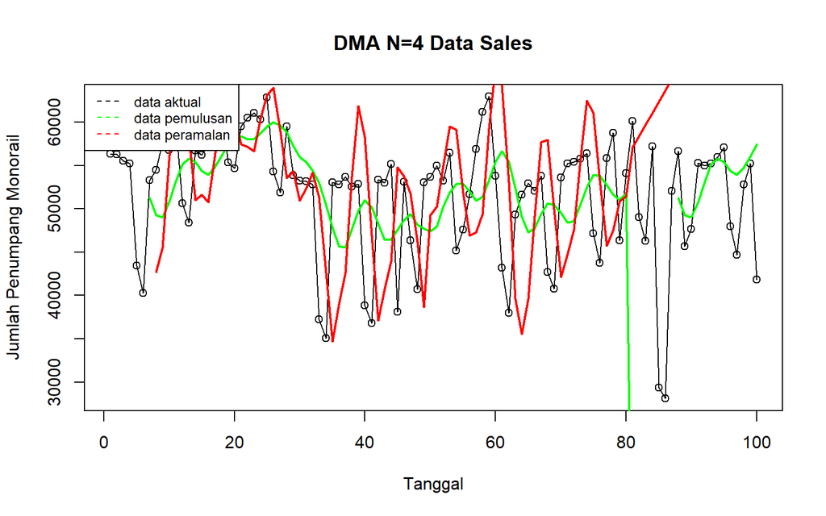

```r
ts.plot(data.ts, xlab="Tanggal", ylab="Jumlah Penumpang Monorail", main= "DMA N=4 Data Sales")
points(data.ts)
lines(data.gab2[,3],col="green",lwd=2)
lines(data.gab2[,6],col="red",lwd=2)
legend("topleft",c("data aktual","data pemulusan","data peramalan"), lty=8, col=c("black","green","red"), cex=0.8)
```

Selanjutnya perhitungan akurasi dilakukan baik pada data latih maupun data uji. Perhitungan akurasi dilakukan dengan ukuran akurasi SSE, MSE dan MAPE.

```r
#Menghitung nilai keakuratan data latih
error_train.dma = train_ma.ts-data.ramal2[1:length(train_ma.ts)]

SSE_train.dma = sum(error_train.dma[8:length(train_ma.ts)]^2)
MSE_train.dma = mean(error_train.dma[8:length(train_ma.ts)]^2)
MAPE_train.dma = mean(abs((error_train.dma[8:length(train_ma.ts)]/train_ma.ts[8:length(train_ma.ts)])*100))

akurasi_train.dma <- matrix(c(SSE_train.dma, MSE_train.dma, MAPE_train.dma))
row.names(akurasi_train.dma)<- c("SSE", "MSE", "MAPE")
colnames(akurasi_train.dma) <- c("Akurasi m = 4")
akurasi_train.dma
```

```
##      Akurasi m = 4
## SSE   6.695815e+09
## MSE   9.172349e+07
## MAPE  1.617862e+01
```

```r
#Menghitung nilai keakuratan data uji
error_test.dma = test_ma.ts-data.gab2[81:100,6]
SSE_test.dma = sum(error_test.dma^2)
MSE_test.dma = mean(error_test.dma^2)
MAPE_test.dma = mean(abs((error_test.dma/test_ma.ts*100)))

akurasi_test.dma <- matrix(c(SSE_test.dma, MSE_test.dma, MAPE_test.dma))
row.names(akurasi_test.dma)<- c("SSE", "MSE", "MAPE")
colnames(akurasi_test.dma) <- c("Akurasi m = 4")
akurasi_test.dma
```

```
##      Akurasi m = 4
## SSE   1.030354e+10
## MSE   5.151768e+08
## MAPE  4.586603e+01
```

Pada data latih dan data uji metode SMA lebih baik daripada metode DMA

## Single Exponential Smoothing & Double Exponential Smoothing

### Pembagian Data

Pembagian data latih dan data uji dilakukan dengan perbandingan 80% data latih dan 20% data uji.

```r
# jumlah baris data
n <- nrow(data)

# hitung batas 80%
n_train <- floor(0.8 * n)

# bagi data
training <- data[1:n_train, ]
testing  <- data[(n_train+1):n, ]

# ubah ke time series
train.ts <- ts(training$'Jumlah Penumpang Monorail')
test.ts  <- ts(testing$'Jumlah Penumpang Monorail')
```

### Eksplorasi

Eksplorasi dilakukan dengan membuat plot data deret waktu untuk keseluruhan data, data latih, dan data uji.

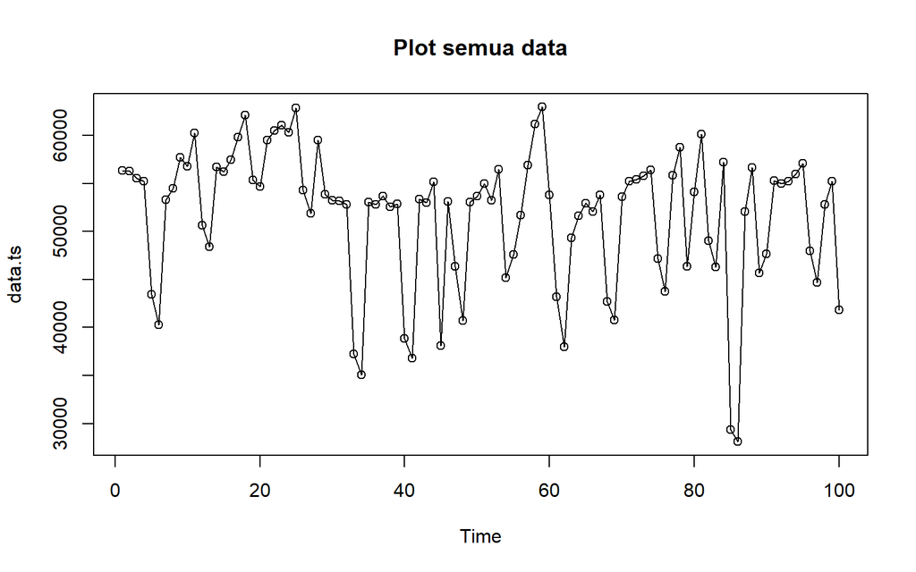

```r
#eksplorasi data
plot(data.ts, col="black",main="Plot semua data")
points(data.ts)
```

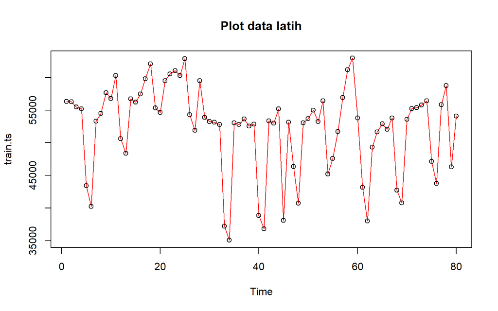

```r
plot(train.ts, col="red",main="Plot data latih")
points(train.ts)
```

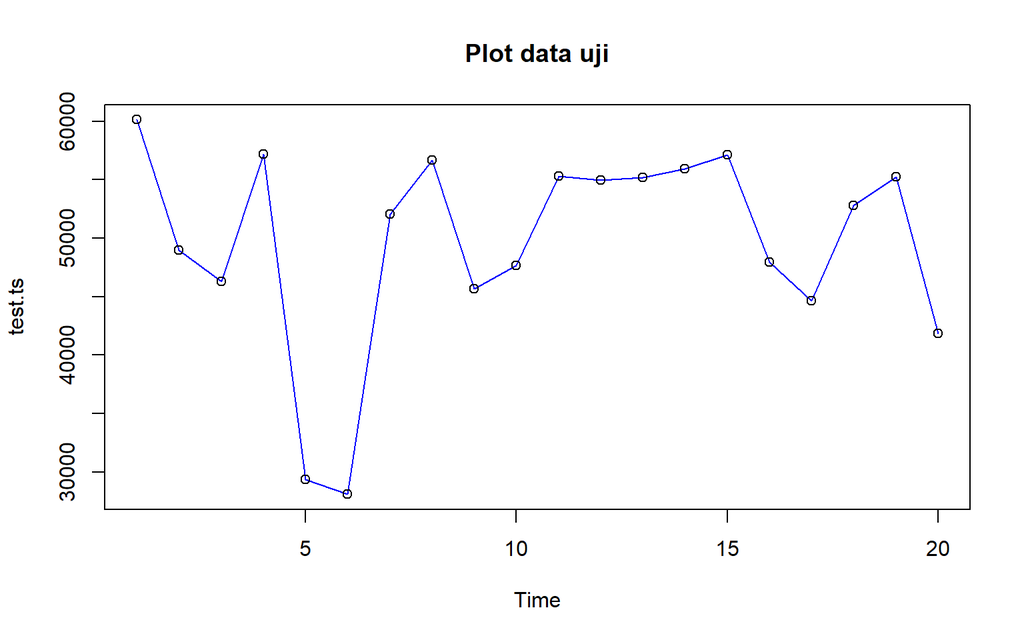

```r
plot(test.ts, col="blue",main="Plot data uji")
points(test.ts)
```

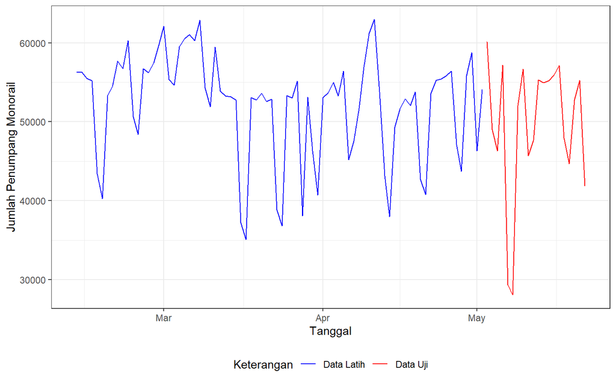

```r
library(ggplot2)

ggplot() +
  geom_line(
    data = training_ma,
    aes(
      x = Tanggal,
      y = `Jumlah Penumpang Monorail`,
      color = "Data Latih"
    )
  ) +
  geom_line(
    data = testing_ma,
    aes(
      x = Tanggal,
      y = `Jumlah Penumpang Monorail`,
      color = "Data Uji"
    )
  ) +
  labs(
    x = "Tanggal",
    y = "Jumlah Penumpang Monorail",
    color = "Keterangan"
  ) +
  scale_colour_manual(
    values = c(
      "Data Latih" = "blue",
      "Data Uji" = "red"
    )
  ) +
  theme_bw() +
  theme(
    legend.position = "bottom"
  )
```

## Single Exponential Smoothing

Single Exponential Smoothing (SES) adalah metode peramalan deret waktu yang dikembangkan untuk mengatasi kelemahan Moving Average. Jika pada Moving Average setiap data periode sebelumnya dianggap memiliki bobot yang sama, maka SES memberikan bobot yang semakin mengecil secara eksponensial terhadap data lama, sehingga data terbaru diberi bobot lebih besar.

Single Exponential Smoothing merupakan metode pemulusan yang tepat digunakan untuk data dengan pola stasioner atau konstan.

Nilai pemulusan pada periode ke-t didapat dari persamaan:

$$\tilde{y}_T=\lambda
y_t+(1-\lambda)\tilde{y}_{T-1}$$

Nilai parameter $\lambda$ adalah nilai antara 0 dan 1.

Nilai pemulusan periode ke-t bertindak sebagai nilai ramalan pada periode ke-$(T+\tau)$.

$$\tilde{y}_{T+\tau}(T)=\tilde{y}_T$$

Pemulusan dengan metode SES dapat dilakukan dengan dua fungsi dari *packages* berbeda, yaitu (1) fungsi `ses()` dari *packages* `forecast` dan (2) fungsi `HoltWinters` dari *packages* `stats` .

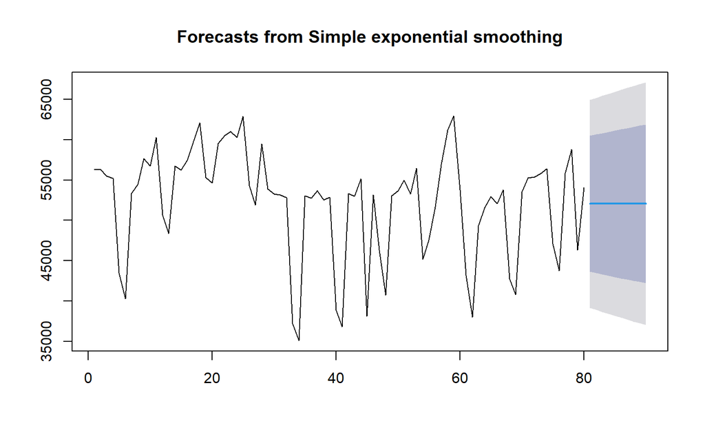

```r
#Cara 1 (fungsi ses)
ses.1 <- ses(train.ts, h = 10, alpha = 0.2)
plot(ses.1)
```

```r
ses.1
```

```
##    Point Forecast    Lo 80    Hi 80    Lo 95    Hi 95
## 81        52052.1 43615.32 60488.88 39149.16 64955.04
## 82        52052.1 43448.24 60655.96 38893.63 65210.57
## 83        52052.1 43284.34 60819.86 38642.97 65461.23
## 84        52052.1 43123.45 60980.75 38396.91 65707.29
## 85        52052.1 42965.41 61138.79 38155.21 65949.00
## 86        52052.1 42810.07 61294.13 37917.64 66186.57
## 87        52052.1 42657.30 61446.90 37683.99 66420.21
## 88        52052.1 42506.98 61597.23 37454.09 66650.11
## 89        52052.1 42358.98 61745.23 37227.75 66876.45
## 90        52052.1 42213.21 61890.99 37004.82 67099.39
```

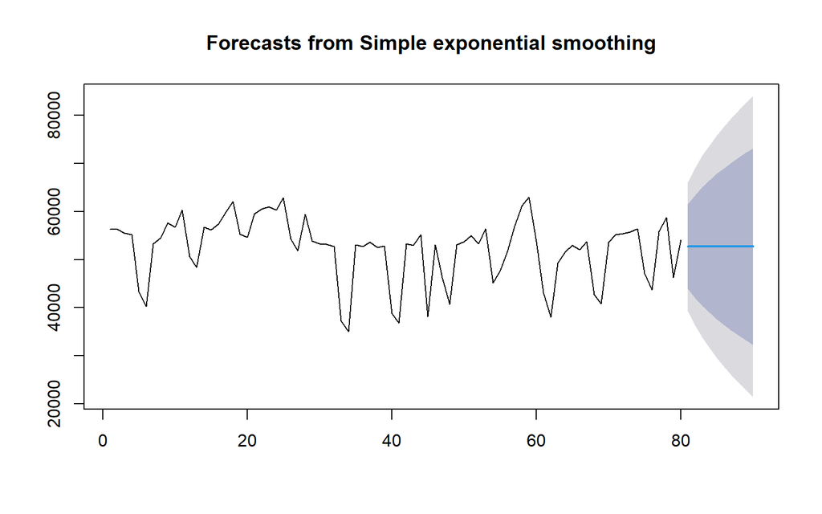

```r
ses.2<- ses(train.ts, h = 10, alpha = 0.7)
plot(ses.2)
```

```r
ses.2
```

```
##    Point Forecast    Lo 80    Hi 80    Lo 95    Hi 95
## 81       52712.67 43912.66 61512.68 39254.22 66171.12
## 82       52712.67 41970.89 63454.45 36284.54 69140.80
## 83       52712.67 40329.96 65095.38 33774.96 71650.38
## 84       52712.67 38882.38 66542.96 31561.06 73864.28
## 85       52712.67 37572.57 67852.77 29557.88 75867.46
## 86       52712.67 36367.39 69057.95 27714.71 77710.63
## 87       52712.67 35245.16 70180.18 25998.42 79426.92
## 88       52712.67 34190.80 71234.54 24385.92 81039.42
## 89       52712.67 33193.31 72232.03 22860.39 82564.95
## 90       52712.67 32244.38 73180.96 21409.12 84016.22
```

Pada fungsi `ses()` , terdapat beberapa argumen yang umum digunakan, yaitu

- `y` : nilai data deret waktu
- `alpha` : parameter pemulusan utama (0–1), mengatur bobot data terbaru vs data lama.
- `beta` : parameter pemulusan tren.
- `gamma` : parameter pemulusan musiman.
- `h` : jumlah periode ke depan yang ingin diramalkan (forecast horizon).

  Kasus di atas merupakan contoh inisialisasi nilai parameter $\lambda$ dengan nilai `alpha` 0,2 dan 0,7 dan banyak periode data yang akan diramalkan adalah sebanyak 10 periode.

Untuk mendapatkan gambar hasil pemulusan pada data latih dengan fungsi `ses()` , perlu digunakan fungsi `autoplot()` dan `autolayer()` dari *library packages* `ggplot2` .

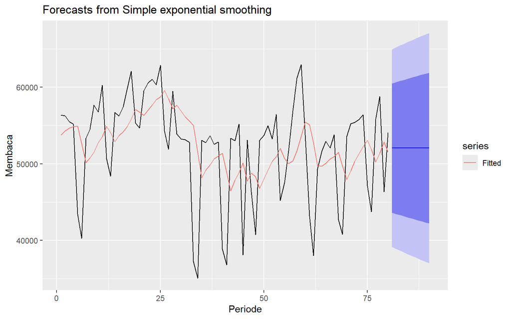

```r
autoplot(ses.1) +
  autolayer(fitted(ses.1), series="Fitted") +
  ylab("Membaca") + xlab("Periode")
```

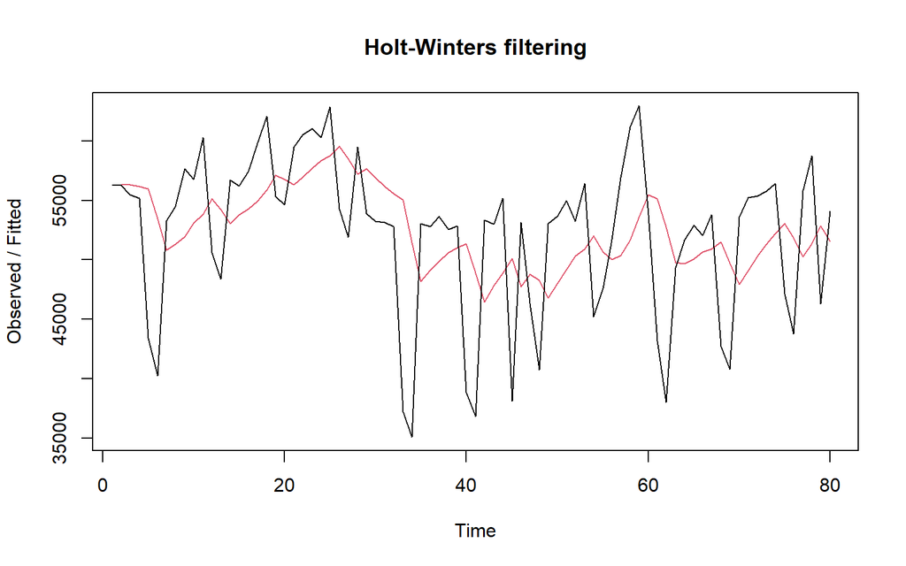

```r
#Cara 2 (fungsi Holtwinter)
ses1<- HoltWinters(train.ts, gamma = FALSE, beta = FALSE, alpha = 0.2)
plot(ses1)
```

```r
#ramalan
ramalan1<- forecast(ses1, h=20)
ramalan1
```

```
##     Point Forecast    Lo 80    Hi 80    Lo 95    Hi 95
##  81        52052.1 43599.48 60504.72 39124.94 64979.27
##  82        52052.1 43432.09 60672.12 38868.93 65235.27
##  83        52052.1 43267.88 60836.32 38617.80 65486.40
##  84        52052.1 43106.69 60997.51 38371.28 65732.93
##  85        52052.1 42948.35 61155.85 38129.12 65975.08
##  86        52052.1 42792.72 61311.48 37891.10 66213.10
##  87        52052.1 42639.67 61464.54 37657.02 66447.18
##  88        52052.1 42489.06 61615.15 37426.69 66677.52
##  89        52052.1 42340.78 61763.42 37199.92 66904.28
##  90        52052.1 42194.74 61909.46 36976.57 67127.64
##  91        52052.1 42050.83 62053.37 36756.48 67347.73
##  92        52052.1 41908.96 62195.24 36539.51 67564.70
##  93        52052.1 41769.05 62335.16 36325.53 67778.68
##  94        52052.1 41631.02 62473.19 36114.43 67989.78
##  95        52052.1 41494.79 62609.42 35906.08 68198.12
##  96        52052.1 41360.29 62743.91 35700.39 68403.81
##  97        52052.1 41227.47 62876.73 35497.26 68606.95
##  98        52052.1 41096.26 63007.95 35296.58 68807.62
##  99        52052.1 40966.60 63137.61 35098.29 69005.92
## 100        52052.1 40838.44 63265.77 34902.28 69201.92
```

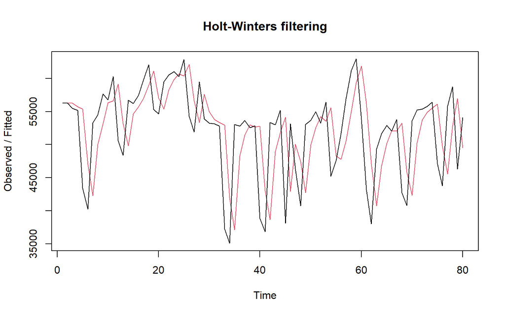

```r
ses2<- HoltWinters(train.ts, gamma = FALSE, beta = FALSE, alpha = 0.7)
plot(ses2)
```

```r
#ramalan
ramalan2<- forecast(ses2, h=20)
ramalan2
```

```
##     Point Forecast    Lo 80    Hi 80     Lo 95    Hi 95
##  81       52712.67 43913.02 61512.32 39254.773 66170.57
##  82       52712.67 41971.33 63454.01 36285.213 69140.13
##  83       52712.67 40330.47 65094.87 33775.731 71649.61
##  84       52712.67 38882.94 66542.40 31561.925 73863.41
##  85       52712.67 37573.19 67852.15 29558.829 75866.51
##  86       52712.67 36368.05 69057.29 27715.736 77709.60
##  87       52712.67 35245.87 70179.47 25999.508 79425.83
##  88       52712.67 34191.56 71233.78 24387.074 81038.27
##  89       52712.67 33194.11 72231.23 22861.611 82563.73
##  90       52712.67 32245.22 73180.12 21410.401 84014.94
##  91       52712.67 31338.40 74086.93 20023.552 85401.79
##  92       52712.67 30468.53 74956.81 18693.194 86732.15
##  93       52712.67 29631.42 75793.92 17412.938 88012.40
##  94       52712.67 28823.62 76601.72 16177.517 89247.82
##  95       52712.67 28042.25 77383.09 14982.526 90442.81
##  96       52712.67 27284.89 78140.45 13824.238 91601.10
##  97       52712.67 26549.44 78875.90 12699.466 92725.87
##  98       52712.67 25834.11 79591.23 11605.459 93819.88
##  99       52712.67 25137.33 80288.01 10539.822 94885.52
## 100       52712.67 24457.72 80967.62  9500.455 95924.88
```

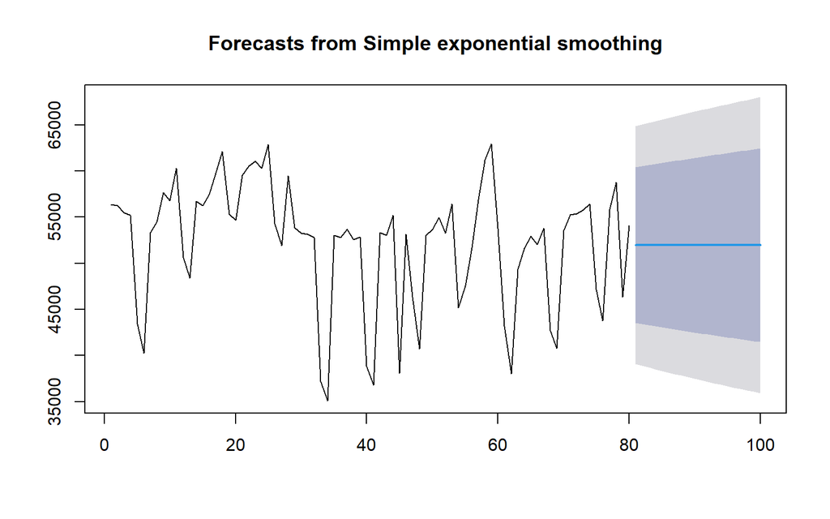

```r
#SES
ses.opt <- ses(train.ts, h = 20, alpha = NULL)
plot(ses.opt)
```

```r
ses.opt
```

```
##     Point Forecast    Lo 80    Hi 80    Lo 95    Hi 95
##  81       51960.71 43528.75 60392.66 39065.15 64856.26
##  82       51960.71 43407.69 60513.72 38880.00 65041.41
##  83       51960.71 43288.32 60633.09 38697.43 65223.98
##  84       51960.71 43170.56 60750.85 38517.34 65404.07
##  85       51960.71 43054.37 60867.04 38339.64 65581.77
##  86       51960.71 42939.67 60981.74 38164.22 65757.19
##  87       51960.71 42826.41 61095.00 37991.00 65930.41
##  88       51960.71 42714.54 61206.87 37819.91 66101.50
##  89       51960.71 42604.00 61317.41 37650.86 66270.55
##  90       51960.71 42494.76 61426.65 37483.79 66437.62
##  91       51960.71 42386.76 61534.65 37318.62 66602.79
##  92       51960.71 42279.97 61641.44 37155.30 66766.11
##  93       51960.71 42174.34 61747.07 36993.75 66927.66
##  94       51960.71 42069.84 61851.57 36833.94 67087.48
##  95       51960.71 41966.44 61954.98 36675.79 67245.62
##  96       51960.71 41864.09 62057.32 36519.26 67402.15
##  97       51960.71 41762.77 62158.64 36364.30 67557.11
##  98       51960.71 41662.44 62258.97 36210.87 67710.54
##  99       51960.71 41563.09 62358.32 36058.92 67862.49
## 100       51960.71 41464.67 62456.74 35908.41 68013.00
```

```r
#Lamda Optimum Holt Winter
HWopt<- HoltWinters(train.ts, gamma = FALSE, beta = FALSE,alpha = NULL)
HWopt
```

```
## Holt-Winters exponential smoothing without trend and without seasonal component.
##
## Call:
## HoltWinters(x = train.ts, alpha = NULL, beta = FALSE, gamma = FALSE)
##
## Smoothing parameters:
##  alpha: 0.1818323
##  beta : FALSE
##  gamma: FALSE
##
## Coefficients:
##       [,1]
## a 51999.22
```

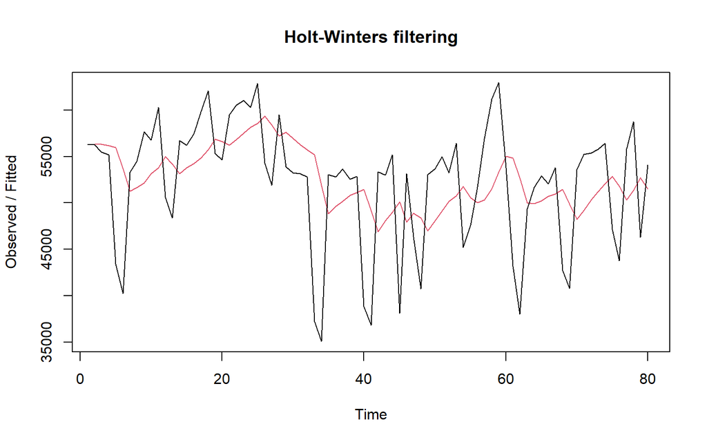

```r
plot(HWopt)
```

```r
#ramalan
ramalanopt<- forecast(HWopt, h=20)
ramalanopt
```

```
##     Point Forecast    Lo 80    Hi 80    Lo 95    Hi 95
##  81       51999.22 43549.99 60448.45 39077.24 64921.20
##  82       51999.22 43411.45 60586.99 38865.36 65133.08
##  83       51999.22 43275.11 60723.34 38656.84 65341.60
##  84       51999.22 43140.86 60857.58 38451.53 65546.91
##  85       51999.22 43008.62 60989.82 38249.29 65749.16
##  86       51999.22 42878.30 61120.14 38049.98 65948.47
##  87       51999.22 42749.81 61248.63 37853.47 66144.97
##  88       51999.22 42623.09 61375.36 37659.66 66338.78
##  89       51999.22 42498.05 61500.39 37468.44 66530.01
##  90       51999.22 42374.64 61623.81 37279.69 66718.75
##  91       51999.22 42252.79 61745.65 37093.34 66905.10
##  92       51999.22 42132.45 61866.00 36909.29 67089.16
##  93       51999.22 42013.55 61984.89 36727.46 67270.99
##  94       51999.22 41896.06 62102.39 36547.76 67450.68
##  95       51999.22 41779.91 62218.53 36370.13 67628.31
##  96       51999.22 41665.07 62333.37 36194.50 67803.94
##  97       51999.22 41551.49 62446.95 36020.80 67977.64
##  98       51999.22 41439.14 62559.31 35848.97 68149.48
##  99       51999.22 41327.97 62670.48 35678.94 68319.50
## 100       51999.22 41217.94 62780.51 35510.67 68487.77
```

Setelah dilakukan peramalan, akan dilakukan perhitungan keakuratan hasil peramalan. Perhitungan akurasi ini dilakukan baik pada data latih dan data uji.

#### Akurasi Data Latih

Perhitungan akurasi data dapat dilakukan dengan cara langsung maupun manual. Secara langsung, nilai akurasi dapat diambil dari objek yang tersimpan pada hasil SES, yaitu *sum of squared errors* (SSE). Nilai akurasi lain dapat dihitung pula dari nilai SSE tersebut.

```r
#Keakuratan Metode
#Pada data training

# SES dengan alpha = 0.2
SSE1<-ses1$SSE
MSE1<-ses1$SSE/length(train.ts)
RMSE1<-sqrt(MSE1)

akurasi1 <- matrix(c(SSE1,MSE1,RMSE1))
row.names(akurasi1)<- c("SSE", "MSE", "RMSE")
colnames(akurasi1) <- c("Akurasi lamda=0.2")
akurasi1
```

```
##      Akurasi lamda=0.2
## SSE       3.398991e+09
## MSE       4.248739e+07
## RMSE      6.518235e+03
```

```r
# SES dengan alpha = 0.7
SSE2<-ses2$SSE
MSE2<-ses2$SSE/length(train.ts)
RMSE2<-sqrt(MSE2)

akurasi2 <- matrix(c(SSE2,MSE2,RMSE2))
row.names(akurasi2)<- c("SSE", "MSE", "RMSE")
colnames(akurasi2) <- c("Akurasi lamda=0.7")
akurasi2
```

```
##      Akurasi lamda=0.7
## SSE       3.677841e+09
## MSE       4.597302e+07
## RMSE      6.780341e+03
```

```r
#Cara Manual
# Alpha = 0.2
fitted1<-ramalan1$fitted
sisaan1<-ramalan1$residuals
head(sisaan1)
```

```
## Time Series:
## Start = 1
## End = 6
## Frequency = 1
## [1]        NA    -64.00   -824.20   -963.36 -12532.69 -13209.15
```

```r
resid1<-training$'Jumlah Penumpang Monorail'-ramalan1$fitted
head(resid1)
```

```
## Time Series:
## Start = 1
## End = 6
## Frequency = 1
## [1]        NA    -64.00   -824.20   -963.36 -12532.69 -13209.15
```

```r
SSE.1=sum(sisaan1[2:length(train.ts)]^2)
SSE.1
```

```
## [1] 3398990842
```

```r
MSE.1 = SSE.1/length(train.ts)
MSE.1
```

```
## [1] 42487386
```

```r
MAPE.1 = sum(abs(sisaan1[2:length(train.ts)]/train.ts[2:length(train.ts)])*
               100)/length(train.ts)
MAPE.1
```

```
## [1] 11.19895
```

```r
akurasi.1 <- matrix(c(SSE.1,MSE.1,MAPE.1))
row.names(akurasi.1)<- c("SSE", "MSE", "MAPE")
colnames(akurasi.1) <- c("Akurasi lamda=0.2")
akurasi.1
```

```
##      Akurasi lamda=0.2
## SSE       3.398991e+09
## MSE       4.248739e+07
## MAPE      1.119895e+01
```

```r
# Alpha = 0.7
fitted2<-ramalan2$fitted
sisaan2<-ramalan2$residuals
head(sisaan2)
```

```
## Time Series:
## Start = 1
## End = 6
## Frequency = 1
## [1]         NA    -64.000   -792.200   -541.660 -11924.498  -6760.349
```

```r
resid2<-training$'Jumlah Penumpang Monorail'-ramalan2$fitted
head(resid2)
```

```
## Time Series:
## Start = 1
## End = 6
## Frequency = 1
## [1]         NA    -64.000   -792.200   -541.660 -11924.498  -6760.349
```

```r
SSE.2=sum(sisaan2[2:length(train.ts)]^2)
SSE.2
```

```
## [1] 3677841484
```

```r
MSE.2 = SSE.2/length(train.ts)
MSE.2
```

```
## [1] 45973019
```

```r
MAPE.2 = sum(abs(sisaan2[2:length(train.ts)]/train.ts[2:length(train.ts)])*
               100)/length(train.ts)
MAPE.2
```

```
## [1] 10.96636
```

```r
akurasi.2 <- matrix(c(SSE.2,MSE.2,MAPE.2))
row.names(akurasi.2)<- c("SSE", "MSE", "MAPE")
colnames(akurasi.2) <- c("Akurasi lamda=0.7")
akurasi.2
```

```
##      Akurasi lamda=0.7
## SSE       3.677841e+09
## MSE       4.597302e+07
## MAPE      1.096636e+01
```

#### Akurasi Data Uji

Akurasi data uji dapat dihitung dengan cara yang hampir sama dengan perhitungan akurasi data latih.

```r
# jumlah observasi uji
n_test <- nrow(testing)

# error (ramalan - aktual), samakan panjang dan tipe numeric
e1   <- as.numeric(ramalan1$mean)[1:n_test] - as.numeric(testing$'Jumlah Penumpang Monorail')
e2   <- as.numeric(ramalan2$mean)[1:n_test] - as.numeric(testing$'Jumlah Penumpang Monorail')
eopt <- as.numeric(ramalanopt$mean)[1:n_test] - as.numeric(testing$'Jumlah Penumpang Monorail')

# SSE / MSE / RMSE untuk masing-masing model (abaikan NA)
SSEtesting1  <- sum(e1^2,  na.rm = TRUE)
MSEtesting1  <- mean(e1^2, na.rm = TRUE)
RMSEtesting1 <- sqrt(MSEtesting1)

SSEtesting2  <- sum(e2^2,  na.rm = TRUE)
MSEtesting2  <- mean(e2^2, na.rm = TRUE)
RMSEtesting2 <- sqrt(MSEtesting2)

SSEtestingopt  <- sum(eopt^2,  na.rm = TRUE)
MSEtestingopt  <- mean(eopt^2, na.rm = TRUE)
RMSEtestingopt <- sqrt(MSEtestingopt)

# Tabel ringkas
akurasitesting_SSE <- matrix(c(SSEtesting1, SSEtesting2, SSEtestingopt),
                             nrow = 3,
                             dimnames = list(c("SSE1","SSE2","SSEopt"), "Nilai"))
akurasitesting_MSE <- matrix(c(MSEtesting1, MSEtesting2, MSEtestingopt),
                             nrow = 3,
                             dimnames = list(c("MSE1","MSE2","MSEopt"), "Nilai"))
akurasitesting_RMSE <- matrix(c(RMSEtesting1, RMSEtesting2, RMSEtestingopt),
                              nrow = 3,
                              dimnames = list(c("RMSE1","RMSE2","RMSEopt"), "Nilai"))

akurasitesting_SSE
```

```
##             Nilai
## SSE1   1560436063
## SSE2   1632441514
## SSEopt 1555426411
```

```r
akurasitesting_MSE
```

```
##           Nilai
## MSE1   78021803
## MSE2   81622076
## MSEopt 77771321
```

```r
akurasitesting_RMSE
```

```
##            Nilai
## RMSE1   8832.995
## RMSE2   9034.494
## RMSEopt 8818.805
```

Selain dengan cara di atas, perhitungan nilai akurasi dapat menggunakan fungsi `accuracy()` dari *package* `forecast` . Penggunaannya yaitu dengan menuliskan `accuracy(hasil ramalan, kondisi aktual)` . Contohnya adalah sebagai berikut.

```r
accuracy(ramalan1, testing$'Jumlah Penumpang Monorail')
```

```
##                      ME     RMSE      MAE       MPE     MAPE     MASE      ACF1
## Training set  -271.5758 6559.360 5420.206 -2.208705 11.34070 1.092404 0.3046669
## Test set     -2394.8525 8832.995 6396.340 -9.173813 16.21603 1.289137        NA
```

```r
accuracy(ramalan2, testing$'Jumlah Penumpang Monorail')
```

```
##                       ME     RMSE      MAE        MPE     MAPE     MASE
## Training set   -65.64792 6823.119 5373.289  -1.459784 11.10518 1.082949
## Test set     -3055.41992 9034.494 6394.450 -10.559283 16.41814 1.288756
##                    ACF1
## Training set 0.04574338
## Test set             NA
```

```r
accuracy(ramalanopt, testing$'Jumlah Penumpang Monorail')
```

```
##                      ME     RMSE      MAE       MPE     MAPE     MASE     ACF1
## Training set  -302.3915 6558.083 5380.456 -2.281908 11.27165 1.084393 0.315231
## Test set     -2341.9726 8818.805 6401.628 -9.062903 16.20971 1.290203       NA
```

## *Double Exponential Smoothing* (DES)

Metode pemulusan *Double Exponential Smoothing* (DES) digunakan untuk data yang memiliki pola tren. Metode DES adalah metode semacam SES, hanya saja dilakukan dua kali, yaitu pertama untuk tahapan ‘level’ dan kedua untuk tahapan ‘tren’. Pemulusan menggunakan metode ini akan menghasilkan peramalan tidak konstan untuk periode berikutnya.

Pemulusan dengan metode DES kali ini akan menggunakan fungsi `HoltWinters()` . Jika sebelumnya nilai argumen `beta` dibuat `FALSE` , kali ini argumen tersebut akan diinisialisasi bersamaan dengan nilai `alpha` .

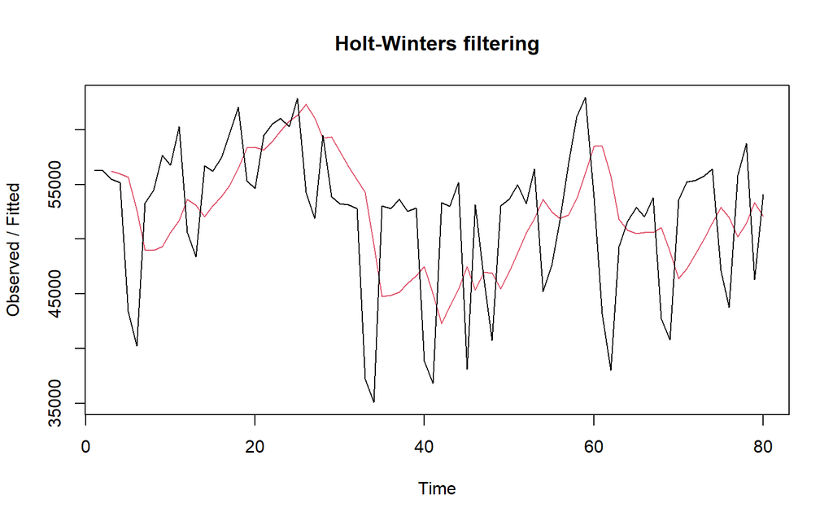

```r
#Lamda=0.2 dan gamma=0.2
des.1<- HoltWinters(train.ts, gamma = FALSE, beta = 0.2, alpha = 0.2)
plot(des.1)
```

```r
#ramalan
ramalandes1<- forecast(des.1, h=20)
ramalandes1
```

```
##     Point Forecast    Lo 80    Hi 80    Lo 95    Hi 95
##  81       52706.12 43569.73 61842.52 38733.21 66679.03
##  82       52922.40 43526.56 62318.23 38552.70 67292.09
##  83       53138.67 43400.80 62876.54 38245.88 68031.46
##  84       53354.94 43187.65 63522.23 37805.41 68904.47
##  85       53571.22 42885.15 64257.28 37228.29 69914.14
##  86       53787.49 42493.78 65081.19 36515.26 71059.72
##  87       54003.76 42015.92 65991.60 35669.94 72337.58
##  88       54220.04 41455.22 66984.86 34697.93 73742.14
##  89       54436.31 40816.03 68056.58 33605.89 75266.72
##  90       54652.58 40103.04 69202.13 32400.97 76904.19
##  91       54868.86 39320.87 70416.84 31090.27 78647.44
##  92       55085.13 38473.97 71696.29 29680.55 80489.70
##  93       55301.40 37566.44 73036.36 28178.12 82424.68
##  94       55517.68 36602.03 74433.32 26588.69 84446.66
##  95       55733.95 35584.11 75883.79 24917.43 86550.47
##  96       55950.22 34515.69 77384.75 23168.93 88731.51
##  97       56166.50 33399.45 78933.54 21347.31 90985.68
##  98       56382.77 32237.79 80527.75 19456.20 93309.33
##  99       56599.04 31032.81 82165.28 17498.86 95699.22
## 100       56815.32 29786.41 83844.22 15478.17 98152.46
```

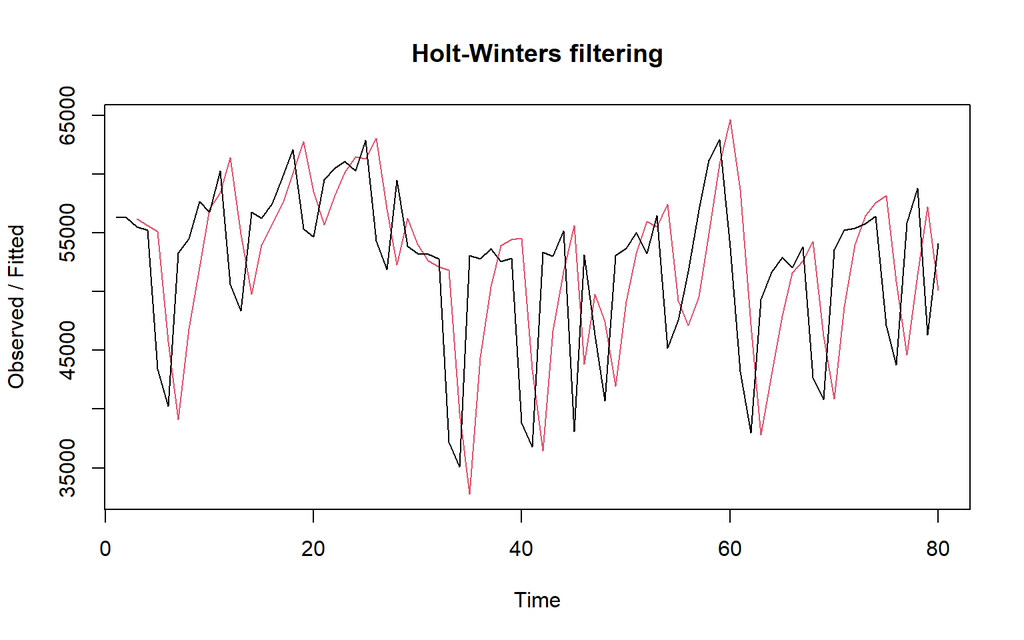

```r
#Lamda=0.6 dan gamma=0.3
des.2<- HoltWinters(train.ts, gamma = FALSE, beta = 0.3, alpha = 0.6)
plot(des.2)
```

```r
#ramalan
ramalandes2<- forecast(des.2, h=20)
ramalandes2
```

```
##     Point Forecast        Lo 80     Hi 80       Lo 95     Hi 95
##  81       52623.06  42595.26371  62650.85   37286.870  67959.25
##  82       52759.21  40041.68797  65476.73   33309.439  72208.98
##  83       52895.36  36945.17583  68845.54   28501.659  77289.06
##  84       53031.51  33407.75415  72655.26   23019.566  83043.45
##  85       53167.66  29496.96731  76838.35   16966.460  89368.86
##  86       53303.81  25258.23742  81349.38   10411.808  96195.81
##  87       53439.96  20723.52360  86156.40    3404.488 103475.43
##  88       53576.11  15916.43699  91235.79   -4019.390 111171.61
##  89       53712.26  10855.20115  96569.32  -11831.956 119256.48
##  90       53848.41   5554.40573 102142.42  -20010.897 127707.72
##  91       53984.56     26.08424 107943.04  -28537.809 136506.93
##  92       54120.71  -5719.59696 113961.02  -37397.144 145638.57
##  93       54256.86 -11673.88103 120187.61  -46575.509 155089.24
##  94       54393.01 -17829.10576 126615.13  -56061.187 164847.22
##  95       54529.17 -24178.47992 133236.81  -65843.790 174902.12
##  96       54665.32 -30715.91988 140046.55  -75914.016 185244.65
##  97       54801.47 -37435.92709 147038.86  -86263.454 195866.39
##  98       54937.62 -44333.49424 154208.73  -96884.446 206759.68
##  99       55073.77 -51404.03189 161551.57 -107769.974 217917.51
## 100       55209.92 -58643.31014 169063.15 -118913.568 229333.40
```

Selanjutnya jika ingin membandingkan plot data latih dan data uji adalah sebagai berikut.

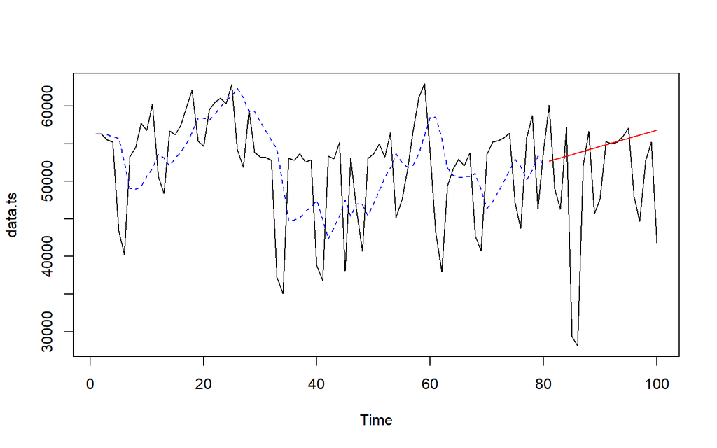

```r
plot(data.ts)
lines(des.1$fitted[,1], lty=2, col="blue")
lines(ramalandes1$mean, col="red")
```

Untuk mendapatkan nilai parameter optimum dari DES, argumen `alpha` dan `beta` dapat dibuat `NULL` seperti berikut.

```r
#Lamda dan gamma optimum
des.opt<- HoltWinters(train.ts, gamma = FALSE)
des.opt
```

```
## Holt-Winters exponential smoothing with trend and without seasonal component.
##
## Call:
## HoltWinters(x = train.ts, gamma = FALSE)
##
## Smoothing parameters:
##  alpha: 0.1754752
##  beta : 0
##  gamma: FALSE
##
## Coefficients:
##       [,1]
## a 51678.13
## b   -64.00
```

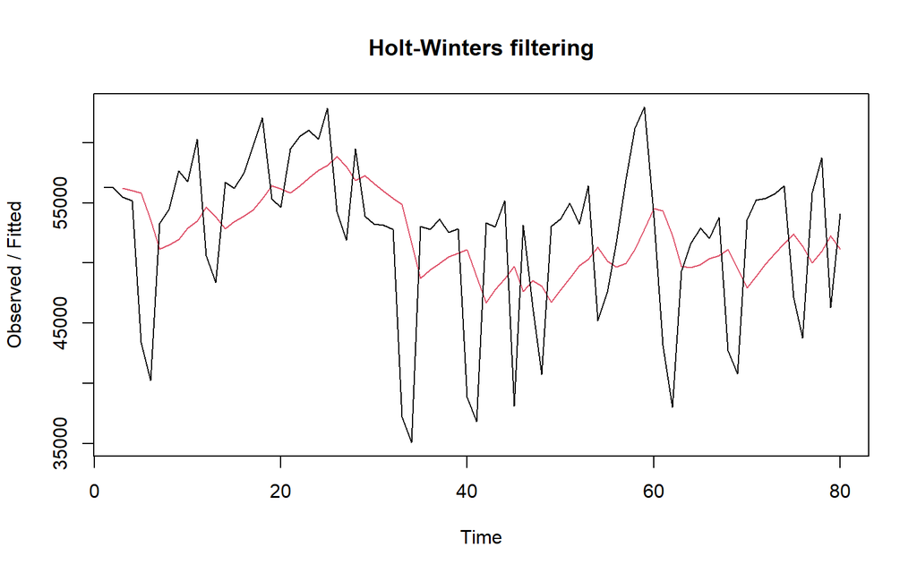

```r
plot(des.opt)
```

```r
#ramalan
ramalandesopt<- forecast(des.opt, h=20)
ramalandesopt
```

```
##     Point Forecast    Lo 80    Hi 80    Lo 95    Hi 95
##  81       51614.13 43104.38 60123.88 38599.59 64628.68
##  82       51550.13 42910.36 60189.91 38336.74 64763.53
##  83       51486.13 42718.26 60254.00 38076.84 64895.43
##  84       51422.13 42528.02 60316.25 37819.76 65024.51
##  85       51358.13 42339.53 60376.73 37565.38 65150.89
##  86       51294.13 42152.75 60435.51 37313.59 65274.67
##  87       51230.13 41967.59 60492.67 37064.30 65395.97
##  88       51166.13 41783.99 60548.27 36817.39 65514.87
##  89       51102.13 41601.91 60602.36 36572.79 65631.47
##  90       51038.13 41421.27 60655.00 36330.41 65745.86
##  91       50974.13 41242.03 60706.24 36090.16 65858.10
##  92       50910.13 41064.13 60756.13 35851.98 65968.29
##  93       50846.13 40887.54 60804.72 35615.79 66076.48
##  94       50782.13 40712.21 60852.05 35381.52 66182.74
##  95       50718.13 40538.10 60898.16 35149.11 66287.15
##  96       50654.13 40365.16 60943.10 34918.51 66389.75
##  97       50590.13 40193.37 60986.89 34689.66 66490.61
##  98       50526.13 40022.68 61029.58 34462.49 66589.77
##  99       50462.13 39853.07 61071.20 34236.97 66687.30
## 100       50398.13 39684.49 61111.77 34013.03 66783.23
```

Selanjutnya akan dilakukan perhitungan akurasi pada data latih maupun data uji dengan ukuran akurasi SSE, MSE dan MAPE.

#### Akurasi Data Latih

```r
#Akurasi Data Training
ssedes.train1<-des.1$SSE
msedes.train1<-ssedes.train1/length(train.ts)
sisaandes1<-ramalandes1$residuals
head(sisaandes1)
```

```
## Time Series:
## Start = 1
## End = 6
## Frequency = 1
## [1]        NA        NA   -709.00   -778.84 -12261.56 -12378.27
```

```r
mapedes.train1 <- sum(abs(sisaandes1[3:length(train.ts)]/train.ts[3:length(train.ts)])
                      *100)/length(train.ts)

akurasides.1 <- matrix(c(ssedes.train1,msedes.train1,mapedes.train1))
row.names(akurasides.1)<- c("SSE", "MSE", "MAPE")
colnames(akurasides.1) <- c("Akurasi lamda=0.2 dan gamma=0.2")
akurasides.1
```

```
##      Akurasi lamda=0.2 dan gamma=0.2
## SSE                     3.914155e+09
## MSE                     4.892693e+07
## MAPE                    1.207212e+01
```

```r
ssedes.train2<-des.2$SSE
msedes.train2<-ssedes.train2/length(train.ts)
sisaandes2<-ramalandes2$residuals
head(sisaandes2)
```

```
## Time Series:
## Start = 1
## End = 6
## Frequency = 1
## [1]         NA         NA   -709.000   -395.980 -11657.496  -5484.753
```

```r
mapedes.train2 <- sum(abs(sisaandes2[3:length(train.ts)]/train.ts[3:length(train.ts)])
                      *100)/length(train.ts)

akurasides.2 <- matrix(c(ssedes.train2,msedes.train2,mapedes.train2))
row.names(akurasides.2)<- c("SSE", "MSE", "MAPE")
colnames(akurasides.2) <- c("Akurasi lamda=0.6 dan gamma=0.3")
akurasides.2
```

```
##      Akurasi lamda=0.6 dan gamma=0.3
## SSE                     4.714448e+09
## MSE                     5.893060e+07
## MAPE                    1.221637e+01
```

#### Akurasi Data Uji

```r
#Akurasi Data Testing
selisihdes1<-ramalandes1$mean-testing$'Jumlah Penumpang Monorail'
selisihdes1
```

```
## Time Series:
## Start = 81
## End = 100
## Frequency = 1
##  [1] -7418.8776  3922.3957  6832.6690 -3845.0577 24220.2156 25690.4889
##  [7]  1932.7622 -2439.9645  8747.3088  6978.5821  -429.1446   115.1287
## [13]   105.4020  -421.3247 -1379.0515  7997.2218 11501.4951  3603.7684
## [19]  1362.0417 14993.3150
```

```r
SSEtestingdes1<-sum(selisihdes1^2)
MSEtestingdes1<-SSEtestingdes1/length(testing$'Jumlah Penumpang Monorail')
MAPEtestingdes1<-sum(abs(selisihdes1/testing$'Jumlah Penumpang Monorail')*100)/length(testing$'Jumlah Penumpang Monorail')

selisihdes2<-ramalandes2$mean-testing$'Jumlah Penumpang Monorail'
selisihdes2
```

```
## Time Series:
## Start = 81
## End = 100
## Frequency = 1
##  [1] -7501.9421  3759.2084  6589.3589 -4168.4906 23816.6599 25206.8104
##  [7]  1368.9609 -3083.8885  8023.2620  6174.4125 -1313.4370  -849.2865
## [13]  -939.1360 -1545.9855 -2583.8350  6712.3155 10136.4660  2158.6165
## [19]  -163.2330 13387.9175
```

```r
SSEtestingdes2<-sum(selisihdes2^2)
MSEtestingdes2<-SSEtestingdes2/length(testing$'Jumlah Penumpang Monorail')
MAPEtestingdes2<-sum(abs(selisihdes2/testing$'Jumlah Penumpang Monorail')*100)/length(testing$'Jumlah Penumpang Monorail')

selisihdesopt<-ramalandesopt$mean-testing$'Jumlah Penumpang Monorail'
selisihdesopt
```

```
## Time Series:
## Start = 81
## End = 100
## Frequency = 1
##  [1] -8510.8687  2550.1313  5180.1313 -5777.8687 22007.1313 23197.1313
##  [7]  -840.8687 -5493.8687  5413.1313  3364.1313 -4323.8687 -4059.8687
## [13] -4349.8687 -5156.8687 -6394.8687  2701.1313  5925.1313 -2252.8687
## [19] -4774.8687  8576.1313
```

```r
SSEtestingdesopt<-sum(selisihdesopt^2)
MSEtestingdesopt<-SSEtestingdesopt/length(testing$'Jumlah Penumpang Monorail')
MAPEtestingdesopt<-sum(abs(selisihdesopt/testing$'Jumlah Penumpang Monorail')*100)/length(testing$'Jumlah Penumpang Monorail')

akurasitestingdes <-
  matrix(c(SSEtestingdes1,MSEtestingdes1,MAPEtestingdes1,SSEtestingdes2,MSEtestingdes2,
           MAPEtestingdes2,SSEtestingdesopt,MSEtestingdesopt,MAPEtestingdesopt),
         nrow=3,ncol=3)
row.names(akurasitestingdes)<- c("SSE", "MSE", "MAPE")
colnames(akurasitestingdes) <- c("des ske1","des ske2","des opt")
akurasitestingdes
```

```
##          des ske1     des ske2      des opt
## SSE  1.951589e+09 1.791824e+09 1.498501e+09
## MSE  9.757947e+07 8.959121e+07 7.492504e+07
## MAPE 1.747468e+01 1.685535e+01 1.621109e+01
```

#### Perbandingan SES dan DES

```r
MSEfull <-
  matrix(c(MSEtesting1,MSEtesting2,MSEtestingopt,MSEtestingdes1,MSEtestingdes2,
           MSEtestingdesopt),nrow=3,ncol=2)
row.names(MSEfull)<- c("ske 1", "ske 2", "ske opt")
colnames(MSEfull) <- c("ses","des")
MSEfull
```

```
##              ses      des
## ske 1   78021803 97579471
## ske 2   81622076 89591212
## ske opt 77771321 74925041
```

Kedua metode dapat dibandingkan dengan menggunakan ukuran akurasi yang sama. Berdasarkan tabel perbandingan nilai MSE di atas, pada Skenario 1 dan Skenario 2, metode SES memberikan hasil yang lebih baik karena memiliki nilai MSE yang lebih kecil dibandingkan DES. Namun, pada Skenario Optimal (ske opt), metode DES menunjukkan performa terbaik secara keseluruhan dengan menghasilkan nilai MSE terkecil ($74.925.041$), sehingga model DES Optimal terpilih sebagai model paling akurat.

## Pemulusan Data Musiman

```r
# Membagi 100 data: 80 data latih, 20 data uji
training <- data[1:80, 2]
testing  <- data[81:100, 2]

# Mengubah ke format time series harian (misal dengan pola musiman mingguan = 7)
training.ts <- ts(training, frequency = 7)
testing.ts  <- ts(testing, frequency = 7)
```

Kemudian akan dilakukan eskplorasi dengan plot data deret waktu sebagai berikut.

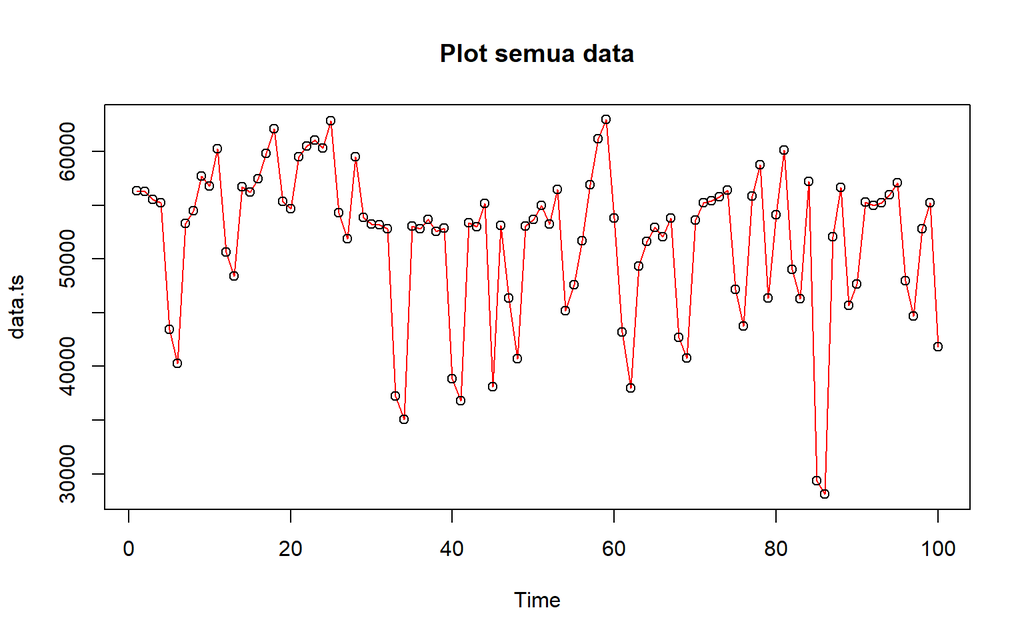

```r
#Membuat plot time series
plot(data.ts, col="red",main="Plot semua data")
points(data.ts)
```

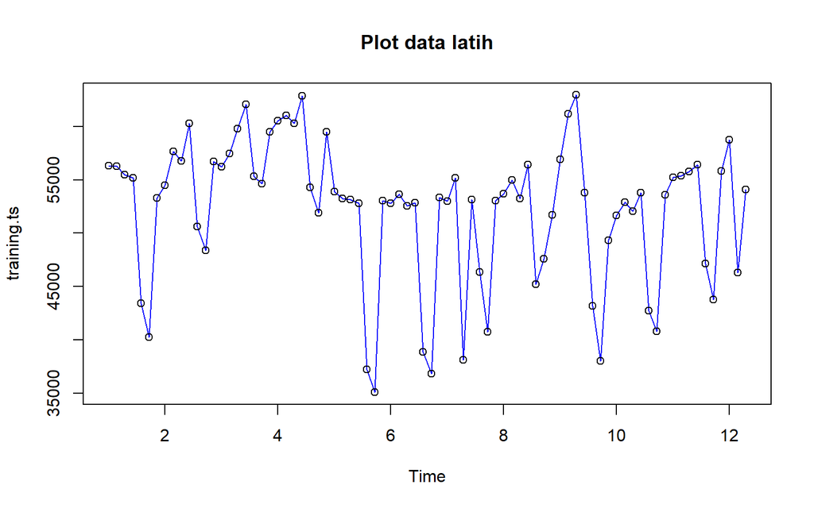

```r
plot(training.ts, col="blue",main="Plot data latih")
points(training.ts)
```

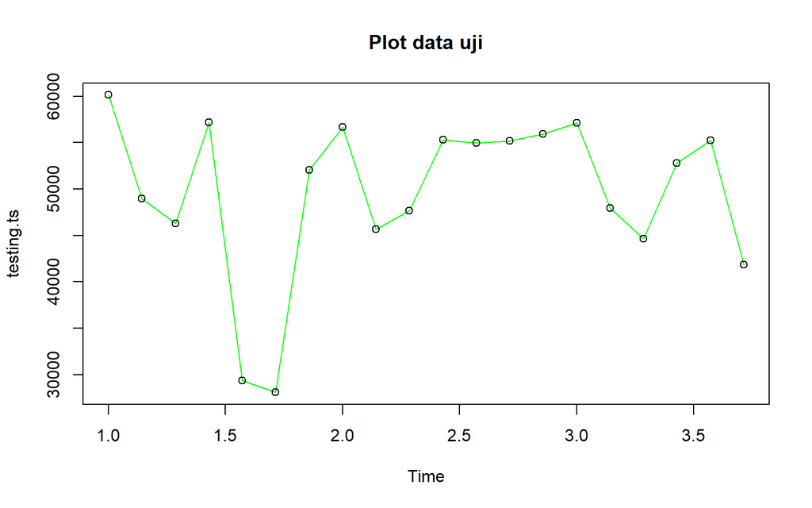

```r
plot(testing.ts, col="green",main="Plot data uji")
points(testing.ts)
```

### Winter Aditif

Perhitungan dengan model aditif dilakukan jika plot data asli menunjukkan fluktuasi musiman yang relatif stabil (konstan).

#### Pemulusan

```r
#Pemulusan dengan winter aditif
winter1 <- HoltWinters(training.ts,alpha=0.2,beta=0.1,gamma=0.1,seasonal = "additive")
winter1$fitted
```

```
## Time Series:
## Start = c(2, 1)
## End = c(12, 3)
## Frequency = 7
##               xhat    level        trend     season
##  2.000000 53367.68 50057.71  566.4880952   2743.480
##  2.142857 56341.19 50850.07  589.0744558   4902.051
##  2.285714 55134.83 51707.70  615.9306265   2811.194
##  2.428571 58360.54 52647.27  648.2940935   5064.980
##  2.571429 47154.00 53677.85  686.5232708  -7210.378
##  2.714286 45223.51 55061.38  756.2232902 -10594.092
##  2.857143 59550.14 56448.10  819.2731256   2282.765
##  3.000000 60299.82 56703.14  762.8503885   2833.825
##  3.142857 62342.08 56651.23  681.3739965   5009.476
##  3.285714 59881.89 56357.39  583.8523896   2940.648
##  3.428571 62723.87 56923.86  582.1146155   5217.896
##  3.571429 51016.84 57379.00  569.4171328  -6931.577
##  3.714286 49126.60 58812.65  655.8402794 -10341.892
##  3.857143 63398.97 60575.37  766.5282916   2057.074
##  4.000000 63763.63 60566.71  689.0087984   2507.919
##  4.142857 65851.61 60607.99  624.2361257   4619.389
##  4.285714 63731.82 60270.10  528.0238689   2933.697
##  4.428571 65736.93 60110.56  459.2674386   5167.106
##  4.571429 53814.02 59997.84  402.0687511  -6585.885
##  4.714286 51010.41 60497.70  411.8482513  -9899.140
##  4.857143 63264.77 61088.07  429.6999976   1746.996
##  5.000000 63363.21 60760.42  353.9646580   2248.829
##  5.142857 63615.70 59216.94  164.2204454   4234.540
##  5.285714 59924.92 57309.22  -42.9735630   2658.671
##  5.428571 60673.96 55913.86 -178.2119121   4938.312
##  5.571429 47276.20 54158.86 -335.8911670  -6546.767
##  5.714286 41444.34 51809.33 -537.2551774  -9827.733
##  5.857143 50778.28 49998.80 -664.5819507   1444.055
##  6.000000 50658.83 49788.17 -619.1875001   1489.852
##  6.142857 52422.87 49593.81 -576.7041276   3405.764
##  6.285714 50828.75 49263.13 -552.1015928   2117.718
##  6.428571 52844.54 49054.68 -517.7365994   4307.595
##  6.571429 40669.29 48539.04 -517.5274142  -7352.223
##  6.714286 36768.68 47659.45 -553.7331671 -10337.041
##  6.857143 48185.61 47112.98 -553.0067535   1625.633
```

[output cut: 23 more lines]

```
## 10.285714 52663.84 50676.77 -106.1658928   2093.233
## 10.428571 54539.78 50447.84 -118.4426454   4210.390
## 10.571429 42956.06 50179.04 -133.4783252  -7089.501
## 10.714286 39871.96 49996.35 -138.3994846  -9985.992
## 10.857143 51548.86 50041.36 -120.0586029   1627.557
## 11.000000 52537.87 50328.33  -79.3557203   2288.900
## 11.142857 54930.64 50791.00  -25.1531474   4164.798
## 11.285714 52886.98 50858.72  -15.8659789   2044.126
## 11.428571 55618.32 51425.65   42.4145040   4150.247
## 11.571429 44574.15 51625.21   58.1281838  -7109.186
## 11.714286 42393.10 52196.30  109.4252203  -9912.629
## 11.857143 54503.60 52576.71  136.5232014   1790.369
## 12.000000 55649.47 52980.51  163.2511672   2505.710
## 12.142857 58196.36 53768.67  225.7416938   4201.946
## 12.285714 53886.14 51620.54  -11.6454393   2277.248
```

```r
xhat1 <- winter1$fitted[,2]

winter1.opt<- HoltWinters(training.ts, alpha= NULL,  beta = NULL, gamma = NULL, seasonal = "additive")
winter1.opt
```

```
## Holt-Winters exponential smoothing with trend and additive seasonal component.
##
## Call:
## HoltWinters(x = training.ts, alpha = NULL, beta = NULL, gamma = NULL,     seasonal = "additive")
##
## Smoothing parameters:
##  alpha: 0.530791
##  beta : 0.02538215
##  gamma: 0
##
## Coefficients:
##            [,1]
## a   49686.48667
## b      39.87639
## s1   5064.97959
## s2  -7210.37755
## s3 -10594.09184
## s4   2282.76531
## s5   2743.47959
## s6   4902.05102
## s7   2811.19388
```

```r
winter1.opt$fitted
```

```
## Time Series:
## Start = c(2, 1)
## End = c(12, 3)
## Frequency = 7
##               xhat    level      trend     season
##  2.000000 53367.68 50057.71 566.488095   2743.480
##  2.142857 56707.39 51223.63 581.702964   4902.051
##  2.285714 55729.77 52323.71 594.860480   2811.194
##  2.428571 59135.32 53461.70 608.646088   5064.980
##  2.571429 48087.26 54673.68 623.960112  -7210.378
##  2.714286 46716.33 56652.08 658.338678 -10594.092
##  2.857143 61154.82 58191.36 680.698821   2282.765
##  3.000000 59887.42 56522.87 621.071417   2743.480
##  3.142857 60674.29 55200.49 571.742491   4902.051
##  3.285714 57409.02 54069.31 528.518486   2811.194
##  3.428571 61489.93 55864.28 560.663905   5064.980
##  3.571429 50101.29 56742.93 568.735008  -7210.378
##  3.714286 50136.46 60091.26 639.287238 -10594.092
##  3.857143 66115.15 63132.14 700.244631   2282.765
##  4.000000 63688.24 60333.33 611.431170   2743.480
##  4.142857 64736.61 59265.74 568.814049   4902.051
##  4.285714 61203.18 57872.96 519.024563   2811.194
##  4.428571 63481.16 57909.40 506.775540   5064.980
##  4.571429 51383.75 58095.50 498.635973  -7210.378
##  4.714286 50087.52 60143.64 537.965848 -10594.092
##  4.857143 64490.44 61645.25 562.425178   2282.765
##  5.000000 62785.49 59547.12 494.894491   2743.480
##  5.142857 60589.85 55312.93 374.860338   4902.051
##  5.285714 54882.30 51795.06 276.054254   2811.194
##  5.428571 56476.39 51158.52 252.890737   5064.980
##  5.571429 42447.56 49454.71 203.225430  -7210.378
##  5.714286 36415.37 46876.82 132.634911 -10594.092
##  5.857143 48696.98 46299.60 114.617075   2282.765
##  6.000000 51640.41 48723.70 173.236711   2743.480
##  6.142857 54594.09 49503.41 188.630351   4902.051
##  6.285714 52179.66 49192.52 175.951413   2811.194
##  6.428571 54809.33 49563.45 180.900418   5064.980
##  6.571429 41651.20 48707.01 154.570509  -7210.378
##  6.714286 36902.36 47379.50 116.952249 -10594.092
##  6.857143 49843.18 47444.78 115.640499   2282.765
```

[output cut: 23 more lines]

```
## 10.285714 51250.08 48393.46  45.421717   2811.194
## 10.428571 53984.65 48863.47  56.198777   5064.980
## 10.571429 41658.46 48815.29  53.549343  -7210.378
## 10.714286 38900.61 49426.99  67.716288 -10594.092
## 10.857143 52872.97 50497.04  93.157819   2282.765
## 11.000000 53813.83 50967.61 102.737306   2743.480
## 11.142857 56855.70 51831.59 122.059354   4902.051
## 11.285714 54091.90 51178.32 102.379844   2811.194
## 11.428571 57378.27 52187.88 125.405914   5064.980
## 11.571429 44698.06 51796.15 112.280006  -7210.378
## 11.714286 42755.14 53204.07 145.165893 -10594.092
## 11.857143 56317.54 53876.23 158.542325   2282.765
## 12.000000 56676.89 53781.30 152.108609   2743.480
## 12.142857 60128.95 55046.54 180.362180   4902.051
## 12.285714 50706.56 47900.95  -5.586198   2811.194
```

```r
xhat1.opt <- winter1.opt$fitted[,2]
```

#### Peramalan

```r
# Tentukan jumlah data uji secara dinamis agar aman
h_uji <- length(testing.ts) # atau langsung tulis angka 20

# Menggunakan fungsi forecast dengan h yang sesuai (20 periode ke depan)
forecast1     <- forecast(winter1, h = h_uji)
forecast1.opt <- forecast(winter1.opt, h = h_uji)
```

#### Plot Deret Waktu

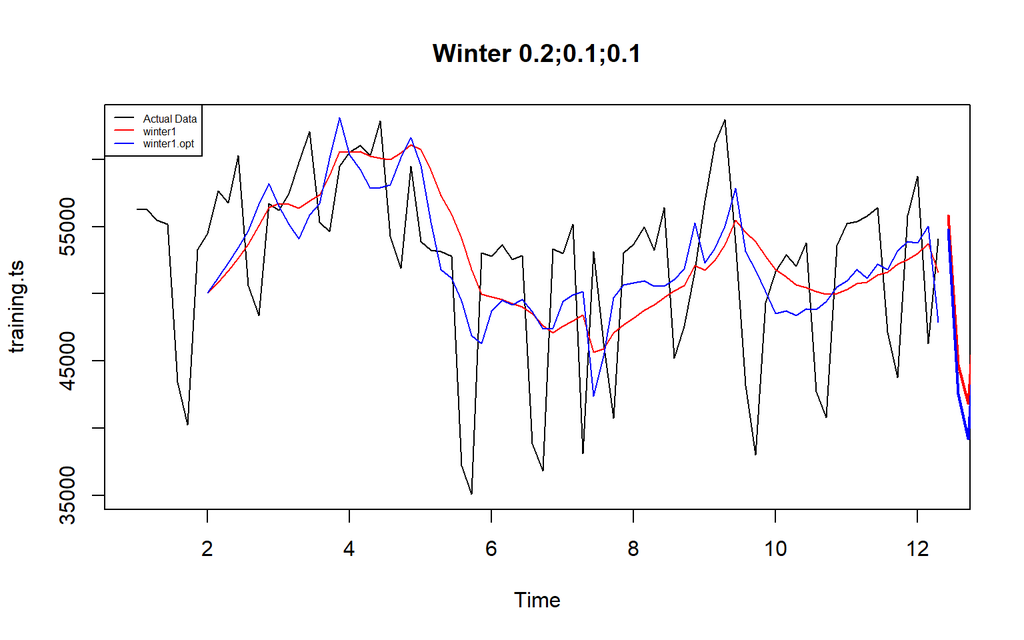

```r
#Plot time series
plot(training.ts,main="Winter 0.2;0.1;0.1",type="l",col="black",pch=12)
lines(xhat1,type="l",col="red")
lines(xhat1.opt,type="l",col="blue")
lines(forecast1$mean, type="l", col="red", lwd=2)
lines(forecast1.opt$mean, type="l", col="blue", lwd=2)
legend("topleft",c("Actual Data",expression(paste(winter1)),
                   expression(paste(winter1.opt))),cex=0.5,
       col=c("black","red","blue"),lty=1)
```

#### Akurasi Data Latih

```r
# Akurasi data training
SSE1 <- winter1$SSE
MSE1 <- winter1$SSE / length(training.ts)
RMSE1 <- sqrt(MSE1)

# Menghitung MAPE training untuk Winter 1
# Menggunakan winter1$fitted untuk nilai taksiran dalam sampel
MAPE1 <- mean(abs((training.ts - winter1$fitted) / training.ts) * 100, na.rm = TRUE)

akurasi1 <- matrix(c(SSE1, MSE1, RMSE1, MAPE1))
row.names(akurasi1) <- c("SSE", "MSE", "RMSE", "MAPE")
colnames(akurasi1) <- c("Akurasi")
akurasi1
```

```
##           Akurasi
## SSE  1.525972e+09
## MSE  1.907465e+07
## RMSE 4.367454e+03
## MAPE 5.476879e+01
```

```r
SSE1.opt <- winter1.opt$SSE
MSE1.opt <- winter1.opt$SSE / length(training.ts)
RMSE1.opt <- sqrt(MSE1.opt)

# Menghitung MAPE training untuk Winter Optimal
MAPE1.opt <- mean(abs((training.ts - winter1.opt$fitted) / training.ts) * 100, na.rm = TRUE)

akurasi1.opt <- matrix(c(SSE1.opt, MSE1.opt, RMSE1.opt, MAPE1.opt))
row.names(akurasi1.opt) <- c("SSE", "MSE", "RMSE", "MAPE") # Dirapikan agar seragam
colnames(akurasi1.opt) <- c("Akurasi")
akurasi1.opt
```

```
##           Akurasi
## SSE  1.228940e+09
## MSE  1.536176e+07
## RMSE 3.919408e+03
## MAPE 5.417228e+01
```

```r
# Membuat data frame perbandingan gabungan dengan MAPE
akurasi1.train <- data.frame(
  Model_Winter = c("Winter 1", "Winter1 optimal"),
  Nilai_SSE = c(SSE1, SSE1.opt),
  Nilai_MSE = c(MSE1, MSE1.opt),
  Nilai_RMSE = c(RMSE1, RMSE1.opt),
  Nilai_MAPE = c(MAPE1, MAPE1.opt)
)
akurasi1.train
```

```
##      Model_Winter  Nilai_SSE Nilai_MSE Nilai_RMSE Nilai_MAPE
## 1        Winter 1 1525972078  19074651   4367.454   54.76879
## 2 Winter1 optimal 1228940492  15361756   3919.408   54.17228
```

#### Akurasi Data Uji

```r
# 1. Pastikan peramalan di-generate ulang
h_uji <- length(testing.ts)
forecast1     <- forecast(winter1, h = h_uji)
forecast1.opt <- forecast(winter1.opt, h = h_uji)

# 2. Ambil data aktual testing (pastikan baris 81:100 sesuai dengan data kamu)
nilai_aktual <- as.numeric(data[81:100, 2])

# 3. Ambil nilai mean forecast langsung sebagai vektor numerik (tanpa bungkus data.frame dulu biar aman)
pred1     <- as.numeric(forecast1$mean)
pred1.opt <- as.numeric(forecast1.opt$mean)

# --- Akurasi Testing Winter 1 ---
selisih1     <- pred1 - nilai_aktual
SSEtesting1  <- sum(selisih1^2, na.rm = TRUE)
MSEtesting1  <- SSEtesting1 / length(nilai_aktual)
MAPEtesting1 <- mean(abs(selisih1 / nilai_aktual) * 100, na.rm = TRUE)

# --- Akurasi Testing Winter Optimal ---
selisih1.opt     <- pred1.opt - nilai_aktual
SSEtesting1.opt  <- sum(selisih1.opt^2, na.rm = TRUE)
MSEtesting1.opt  <- SSEtesting1.opt / length(nilai_aktual)
MAPEtesting1.opt <- mean(abs(selisih1.opt / nilai_aktual) * 100, na.rm = TRUE)

# 4. Tampilkan hasil akhirnya
cat("SSE Testing Winter 1:", SSEtesting1, "\n")
```

```
## SSE Testing Winter 1: 1650263677
```

```r
cat("MSE Testing Winter 1:", MSEtesting1, "\n")
```

```
## MSE Testing Winter 1: 82513184
```

```r
cat("MAPE Testing Winter 1:", MAPEtesting1, "%\n\n")
```

```
## MAPE Testing Winter 1: 14.54277 %
```

```r
cat("SSE Testing Winter Optimal:", SSEtesting1.opt, "\n")
```

```
## SSE Testing Winter Optimal: 1740159872
```

```r
cat("MSE Testing Winter Optimal:", MSEtesting1.opt, "\n")
```

```
## MSE Testing Winter Optimal: 87007994
```

```r
cat("MAPE Testing Winter Optimal:", MAPEtesting1.opt, "%\n")
```

```
## MAPE Testing Winter Optimal: 16.14868 %
```

```r
akurasi_testing <- data.frame(
  Model = c("Model1", "Model Optimum"),
  SSE   = c(SSEtesting1, SSEtesting1.opt),
  MSE   = c(MSEtesting1, MSEtesting1.opt)
)

akurasi_testing
```

```
##           Model        SSE      MSE
## 1        Model1 1650263677 82513184
## 2 Model Optimum 1740159872 87007994
```

### Winter Multiplikatif

Model multiplikatif digunakan cocok digunakan jika plot data asli menunjukkan fluktuasi musiman yang bervariasi.

#### Pemulusan

```r
#Pemulusan dengan winter multiplikatif
winter2 <- HoltWinters(training.ts,alpha=0.2,beta=0.1,gamma=0.3,seasonal = "multiplicative")
winter2$fitted
```

```
## Time Series:
## Start = c(2, 1)
## End = c(12, 3)
## Frequency = 7
##               xhat    level       trend    season
##  2.000000 53397.90 50057.71  566.488095 1.0547899
##  2.142857 56302.25 50832.60  587.328355 1.0949499
##  2.285714 55126.75 51672.32  612.566931 1.0543534
##  2.428571 58444.62 52593.37  643.415291 1.0978239
##  2.571429 46591.81 53569.70  676.706314 0.8588921
##  2.714286 44367.75 55188.82  770.948501 0.7928508
##  2.857143 60523.37 56970.87  872.058365 1.0463400
##  3.000000 61391.02 57117.66  799.531792 1.0599791
##  3.142857 63488.03 56942.64  702.076687 1.1013676
##  3.285714 60673.92 56551.17  592.721189 1.0617745
##  3.428571 63655.90 56978.33  576.165491 1.1060109
##  3.571429 50677.89 57271.15  547.831281 0.8764922
##  3.714286 48208.87 58882.34  654.166806 0.8097363
##  3.857143 63826.56 61130.14  813.530611 1.0303967
##  4.000000 64201.18 61108.35  729.998595 1.0382098
##  4.142857 66473.64 61130.18  659.180839 1.0758105
##  4.285714 64899.60 60779.39  558.184646 1.0580724
##  4.428571 66998.12 60467.02  471.128266 1.0994446
##  4.571429 54252.72 60188.47  396.161037 0.8954864
##  4.714286 50933.40 60595.86  397.284064 0.8350676
##  4.857143 62477.76 61225.37  420.506046 1.0134947
##  5.000000 62875.48 61053.91  361.309627 1.0237769
##  5.142857 63095.58 59657.12  185.500172 1.0543586
##  5.285714 60281.98 57976.17   -1.145719 1.0397923
##  5.428571 61155.12 56605.71 -138.076458 1.0830118
##  5.571429 48931.57 54922.85 -292.555208 0.8956856
##  5.714286 43166.64 52012.51 -554.333815 0.8388684
##  5.857143 48865.59 49529.71 -747.180167 1.0017027
##  6.000000 48345.52 49617.59 -663.674211 0.9875721
##  6.142857 49950.26 49852.58 -573.807755 1.0136263
##  6.285714 49984.34 50009.36 -500.748491 1.0096088
##  6.428571 51869.05 50016.27 -449.982995 1.0464582
##  6.571429 41510.23 49754.72 -431.139395 0.8415898
##  6.714286 38543.81 48693.53 -494.144604 0.7996743
##  6.857143 48262.70 47764.51 -537.632600 1.0219330
```

[output cut: 23 more lines]

```
## 10.285714 51731.98 50707.02 -172.546156 1.0236970
## 10.428571 52808.05 50596.60 -166.333087 1.0471500
## 10.571429 42649.99 50617.43 -147.616608 0.8450594
## 10.714286 40054.45 50484.02 -146.196343 0.7957129
## 10.857143 50812.12 50522.45 -127.733700 1.0082826
## 11.000000 52880.94 50944.54  -72.751402 1.0394945
## 11.142857 55104.85 51327.21  -27.208955 1.0741686
## 11.285714 52626.07 51354.02  -21.806621 1.0252055
## 11.428571 54684.70 51951.59   40.130793 1.0517963
## 11.571429 44288.85 52318.65   72.823367 0.8453447
## 11.714286 42522.39 53065.79  140.255025 0.7992022
## 11.857143 54829.34 53512.75  170.925891 1.0213410
## 12.000000 56806.34 53881.59  190.716704 1.0505626
## 12.142857 58804.38 54446.89  228.175863 1.0755246
## 12.285714 54438.35 52354.83   -3.848253 1.0398727
```

```r
xhat2 <- winter2$fitted[,2]

winter2.opt<- HoltWinters(training.ts, alpha= NULL,  beta = NULL, gamma = NULL, seasonal = "multiplicative")
winter2.opt$fitted
```

```
## Time Series:
## Start = c(2, 1)
## End = c(12, 3)
## Frequency = 7
##               xhat    level      trend    season
##  2.000000 53397.90 50057.71 566.488095 1.0547899
##  2.142857 56594.87 51107.64 579.540856 1.0949499
##  2.285714 55607.29 52148.65 592.000780 1.0543534
##  2.428571 59118.27 53244.79 605.612705 1.0978239
##  2.571429 47201.92 54337.98 618.777146 0.8588921
##  2.714286 45574.84 56813.33 668.905102 0.7928508
##  2.857143 62607.25 59121.35 713.161512 1.0463400
##  3.000000 61053.70 57228.13 642.788766 1.0549978
##  3.142857 61693.61 55747.92 585.467228 1.0951519
##  3.285714 58084.77 54542.43 537.111281 1.0545615
##  3.428571 61917.17 55831.94 557.426100 1.0980293
##  3.571429 49008.55 56461.97 559.386313 0.8594772
##  3.714286 48462.92 60437.95 651.635115 0.7933090
##  3.857143 68432.41 64714.34 749.503868 1.0453467
##  4.000000 65518.65 61509.71 642.741614 1.0541603
##  4.142857 66253.06 59954.72 583.402601 1.0944023
##  4.285714 62080.87 58328.62 523.745570 1.0548577
##  4.428571 64312.20 58066.47 502.526420 1.0980587
##  4.571429 50294.58 57962.61 486.153897 0.8604900
##  4.714286 48571.02 60609.94 544.506028 0.7942352
##  4.857143 66497.09 63100.78 597.057231 1.0439459
##  5.000000 64350.82 60578.47 512.833930 1.0533548
##  5.142857 62185.17 56477.76 388.267419 1.0935381
##  5.285714 56275.28 53077.77 285.983731 1.0545601
##  5.428571 57353.98 51994.54 249.014794 1.0978192
##  5.571429 43497.16 50314.81 196.938275 0.8611296
##  5.714286 37534.94 47123.41 105.452581 0.7947459
##  5.857143 47825.35 45794.59  66.727195 1.0428253
##  6.000000 50805.42 48184.82 129.462062 1.0515612
##  6.142857 53874.67 49186.77 153.019507 1.0919112
##  6.285714 52062.55 49245.61 150.476469 1.0539812
##  6.428571 54589.94 49609.33 156.234171 1.0969420
##  6.571429 42276.74 49031.79 136.422113 0.8598389
##  6.714286 37654.89 47324.11  86.631066 0.7942270
##  6.857143 49049.02 46914.28  73.226621 1.0438735
```

[output cut: 23 more lines]

```
## 10.285714 51307.28 48756.48  33.434913 1.0515959
## 10.428571 53883.80 49117.59  42.282138 1.0960931
## 10.571429 42282.88 49119.33  41.187331 0.8600983
## 10.714286 39287.72 49390.91  47.407979 0.7946816
## 10.857143 52547.58 50314.77  71.072538 1.0429035
## 11.000000 53603.26 50846.90  83.521177 1.0524802
## 11.142857 56529.84 51655.44 103.096633 1.0921838
## 11.285714 54024.37 51276.48  90.080964 1.0517421
## 11.428571 57282.48 52150.26 111.241019 1.0960742
## 11.571429 44721.60 51889.66 101.201292 0.8601820
## 11.714286 42476.13 53294.69 136.404911 0.7949701
## 11.857143 56671.45 54173.36 156.446061 1.0431007
## 12.000000 56962.63 53960.00 146.461238 1.0527881
## 12.142857 60137.73 54904.69 168.013586 1.0919698
## 12.285714 51777.25 49204.99   9.584412 1.0520716
```

```r
xhat2.opt <- winter2.opt$fitted[,2]
```

#### Peramalan

```r
#Forecast
forecast2 <- predict(winter2, n.ahead = 20)
forecast2.opt <- predict(winter2.opt, n.ahead = 20)
```

#### Plot Deret Waktu

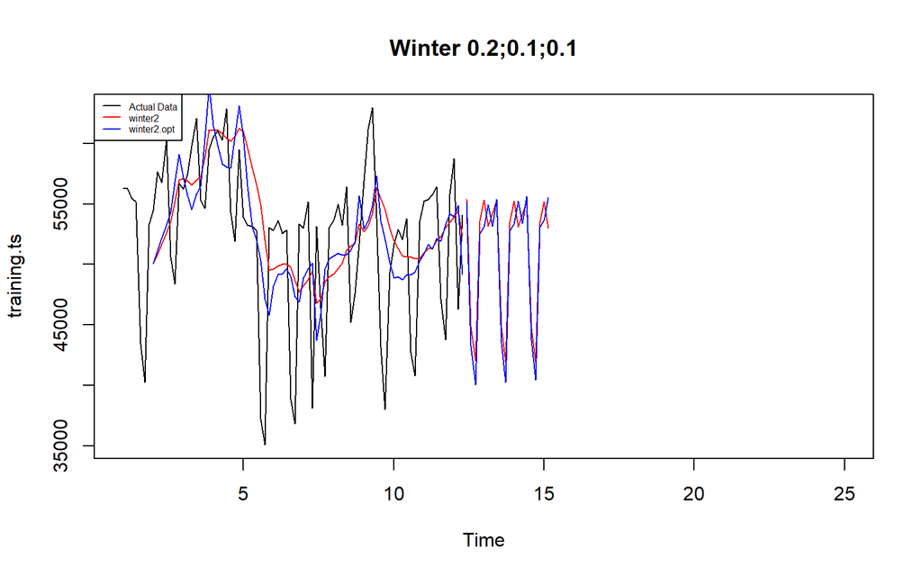

```r
#Plot time series
plot(training.ts,main="Winter 0.2;0.1;0.1",type="l",col="black",
     xlim=c(1,25),pch=12)
lines(xhat2,type="l",col="red")
lines(xhat2.opt,type="l",col="blue")
lines(forecast2,type="l",col="red")
lines(forecast2.opt,type="l",col="blue")
legend("topleft",c("Actual Data",expression(paste(winter2)),
                   expression(paste(winter2.opt))),cex=0.5,
       col=c("black","red","blue"),lty=1)
```

#### Akurasi Data Latih

```r
#Akurasi data training
SSE2<-winter2$SSE
MSE2<-winter2$SSE/length(training.ts)
RMSE2<-sqrt(MSE2)
akurasi1 <- matrix(c(SSE2,MSE2,RMSE2))
row.names(akurasi1)<- c("SSE2", "MSE2", "RMSE2")
colnames(akurasi1) <- c("Akurasi lamda=0.2")
akurasi1
```

```
##       Akurasi lamda=0.2
## SSE2       1.774172e+09
## MSE2       2.217715e+07
## RMSE2      4.709262e+03
```

```r
SSE2.opt<-winter2.opt$SSE
MSE2.opt<-winter2.opt$SSE/length(training.ts)
RMSE2.opt<-sqrt(MSE2.opt)
akurasi1.opt <- matrix(c(SSE2.opt,MSE2.opt,RMSE2.opt))
row.names(akurasi1.opt)<- c("SSE2.opt", "MSE2.opt", "RMSE2.opt")
colnames(akurasi1.opt) <- c("Akurasi")
akurasi1.opt
```

```
##                Akurasi
## SSE2.opt  1.487854e+09
## MSE2.opt  1.859817e+07
## RMSE2.opt 4.312560e+03
```

```r
akurasi2.train = data.frame(Model_Winter = c("Winter 1","winter2 optimal"),
                            Nilai_SSE=c(SSE2,SSE2.opt),
                            Nilai_MSE=c(MSE2,MSE2.opt),Nilai_RMSE=c(RMSE2,RMSE2.opt))
akurasi2.train
```

```
##      Model_Winter  Nilai_SSE Nilai_MSE Nilai_RMSE
## 1        Winter 1 1774172084  22177151   4709.262
## 2 winter2 optimal 1487853948  18598174   4312.560
```

#### Akurasi Data Uji

```r
#Akurasi Data Testing
forecast2<-data.frame(forecast2)
testing.ts<-data.frame(testing.ts)
selisih2<-forecast2-testing.ts
SSEtesting2<-sum(selisih2^2)
MSEtesting2<-SSEtesting2/length(testing.ts)

forecast2.opt<-data.frame(forecast2.opt)
selisih2.opt<-forecast2.opt-testing.ts
SSEtesting2.opt<-sum(selisih2.opt^2)
MSEtesting2.opt<-SSEtesting2.opt/length(testing.ts)
```

```r
# Atau rapikan dalam tabel
akurasi_testing2 <- data.frame(
  Model = c("Model2", "Model2 Optimal"),
  SSE   = c(SSEtesting2, SSEtesting2.opt),
  MSE   = c(MSEtesting2, MSEtesting2.opt)
)

akurasi_testing2
```

```
##            Model        SSE        MSE
## 1         Model2 1572066457 1572066457
## 2 Model2 Optimal 1710010702 1710010702
```